# PEC2_Anàlisi RNAseq amb R

Amelia Martínez Sequera

Juny 2020

https://github.com/gititub/ADO_PEC2.RNAseqAnalysis

## Continguts:

1. Introducció.
2. Selecció de les dades.
3. Anàlisi i visualització exploratòries.  
   3.1 Pre-filtratge del conjunt de dades.  
   3.2 Conversió a DGEList.  
   3.3 Control de qualitat.  
   3.4 Normalització per biaix de composició.
4. Anàlisi de l’expressió diferencial.  
   4.1 Exploració de les dades.  
   4.2 Estimació de la dispersió.  
   4.3 Expressió diferencial.  
   4.4 GLM.
5. Anotació i visualització dels resultats.  
   5.1 Anotació de gens.  
   5.2 Visualització dels resultats.  
   5.3 Recuperació d´ubicacions genòmiques.  
   5.4 Visió general de Genomic Ranges.
6. Exportació de pistes.
7. Anàlisi de significació biològica competitiva(“Gene Enrichment Analysis”).  
   7.1 GOseq.  
   7.2 FGSEA.  
   7.3 CAMERA.
8. Proves de significació biològica autònomes.  
   8.1 ROAST.

# 1. Introducció.

En aquest anàlisi estudiarem els perfils d’expressió a partir d´unes dades preprocessades, és a dir, l´extracció de RNA, preparació de llibreries i la seqüenciació són qüestions que no tractarem. Tanmateix, aquestes seqüències ja han estat alineades amb un genoma de referència, i s´han comptabilitzat el nombre de lectures mapades amb cada gen. Això es tradueix en una taula de recomptes (*counts.csv*), i ens interessa estudiar si aquests difereixen significativament entre els diferents grups o condicions biològiques. Ens interessa, fonamentalment, l´expressió diferencial entre 3 grups, amb 10 mostres o rèpliques cadascun, obtingudes de 54 teixits de tiroides:

- sense infiltració linfoide: NIT,
- localment infiltrat: SFI,
- extensament infiltrats: ELI.

Disposem doncs, de rèpliques tècniques i biològiques.

Les dades en brut no estan prèviament normalitzades. Això és important per seqüenciar la profunditat/mida de la biblioteca, ja que els models estadístics són més potents quan s’apliquen a recomptes no normalitzats, i estan dissenyats per tenir en compte les diferències de mida de la biblioteca (Love et Anders, 2019. *Flux de treball RNA-seq: anàlisi exploratòria a nivell de gens i expressió diferencial.*)

# 2. Selecció de les mostres.

A partir de l´arxiu *targets.csv* hem seleccionat 10 mostres de cada grup segons el tipus d´infiltració (NIT, SFI i ELI), sense tenir en compte el sexe ni el tipus de dades moleculars.

Tot i que ens basarem principalment en la comparació entre grups d´infiltració, hem procurat tenir mostres tant de *RNA Seq(NGS)(Next Generation Sequencing)* com d´*Allele-specific expression* (tipus de dades moleculars segons la llista de dbGap (http://www.ncbi.nlm.nih.gov/gap), base de dades de genotips i fenotips). El segon tipus fa referència a un subconjunt de gens (també SNPs i INDELs) que mostra una desviació a la presentació igual prevista dels al.lels parentals (autosòmics) i expressa preferentment l´al.lel d´un sol progenitor. En canvi, les dades tipus *RNA seq(NGS)* poden ser transcriptomes sencers, exomes,… poden incloure elements tant codificants com no codificants.

Verifiquem que les files de *Sample_Name* es corresponen amb les columnes de l´arxiu *counts.csv* i extraiem la nostra matriu de recompte, sense incorporar la primera columna perquè conté els id de la llibreria (56202 files). Nota: anomenarem “gens” a cada un dels intèrvals genòmics o elements de la llibreria (etiquetes), tot i que a priori no sabem si es tracta de gens o altres tipus de transcrits (ho analitzarem més endavant).

Per fer la selecció, simplement hem agafat els primers valors (de dalt a baix, primer les 3 columnes de l´esquerra i després les últimes columnes)de la matriu lògica. Per exemple, del grup ELI les files 29,100,3,186,211,253,167,251,146,147 de *targets.csv*, que es corresponen a aquestes columnes+1 de l´arxiu *counts.csv*.

Hem fet una nova matriu que conté només els recomptes de 30 mostres, però podem emmagatzemar els identificadors de gens (la primera columna d´EntrezGeneID). Més endavant afegirem més informació sobre anotacions sobre cada gen.

# 3. Anàlisi i visualització exploratòries.

## 3.1. Filtrar gens amb baixa expressió.

Els gens amb un recompte molt baix proporcionen poca evidència per a l’expressió diferencial i interfereixen amb algunes de les aproximacions estadístiques que s’utilitzaran posteriorment en el pipeline. També s’afegeixen a la càrrega de proves múltiples a l’hora d’estimar taxes de descobriment falses (FDR), reduint el poder per detectar gens expressats de manera diferent. Aquests gens s’han de filtrar abans d’analitzar-ne més.

En aquest conjunt de dades, optem per retenir gens si s’expressen en un recompte per milió (CPM) per sobre de 0.1 en almenys 2 mostres, ja que tenim rèpliques biològiques i tècniques de cada grup. S’utilitza un CPM de 0.1 ja que correspon a un recompte de aprox. 10 per a les mides de la biblioteca d’aquest conjunt de dades. Si el recompte és menor, es considera que és molt baix, cosa que indica que el gen associat no s’expressa en aquesta mostra. S’utilitza un requisit d’expressió en dues o més biblioteques. Filtrem amb CPMs en lloc de filtrar els recomptes directament, ja que aquest no té en compte les diferències en les mides de la biblioteca entre les mostres. Per generar els valors de CPM utilitzarem la funció cpm() de la biblioteca edgeR. (Robinson, McCarthy i Smyth, 2010) S´ha de tenir en compte que mitjançant la conversió a CPM estem normalitzant les diferents profunditats de seqüenciació de cada mostra.

```r
col1sum <- sum(mydata[,1])/1000000
mydata[1,1]/col1sum
```

```
##        NIT1
## 1 0.1058108
```

```r
myCPM<- cpm(mydata)
thresh<- myCPM>0.1
# Cuants TRUEs hi ha?
table(rowSums(thresh))
```

```
##
##     0     1     2     3     4     5     6     7     8     9    10    11    12
## 24203  2406  1272   863   649   507   499   447   374   380   311   314   276
##    13    14    15    16    17    18    19    20    21    22    23    24    25
##   269   276   261   278   271   269   259   249   259   316   304   306   316
##    26    27    28    29    30
##   360   435   563   856 17854
```

```r
# mantenim el gens que tenen, al menys, 2 TRUES en cada fila de thresh
keep <- rowSums(thresh) >= 2
# ens quedem amb 29593
counts.keep <- mydata[keep,]
summary(keep)
```

```
##    Mode   FALSE    TRUE
## logical   26609   29593
```

```r
dim(counts.keep)
```

```
## [1] 29593    30
```

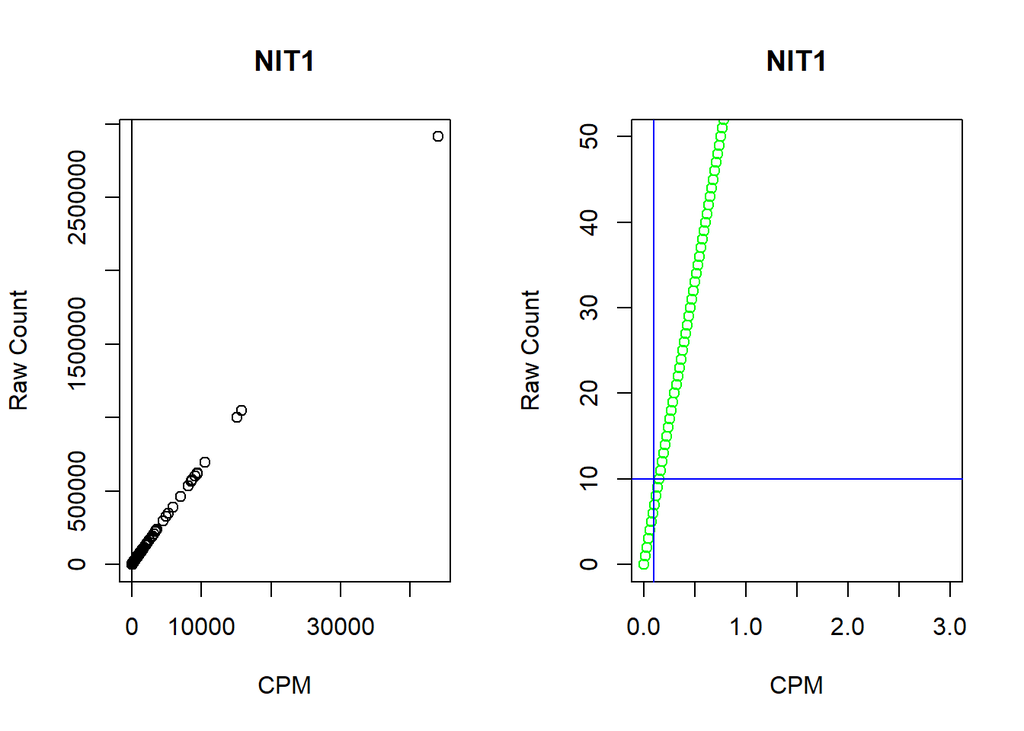

```r
# Comprovem si el nostre llindar de 0.1 correspon a un recompte aproximat a 10. Mirem la primera mostra:
par(mfrow=c(1,2))
plot(myCPM[,1], mydata$NIT1, xlab="CPM", ylab="Raw Count", main=colnames(myCPM)[1])
abline(v=0.1)

plot(myCPM[,1],mydata$NIT1, xlab="CPM", ylab="Raw Count", main=colnames(myCPM)[1],
     ylim=c(0,50), xlim=c(0,3), col="green")
abline(v=0.1, h=10,col="blue")
```

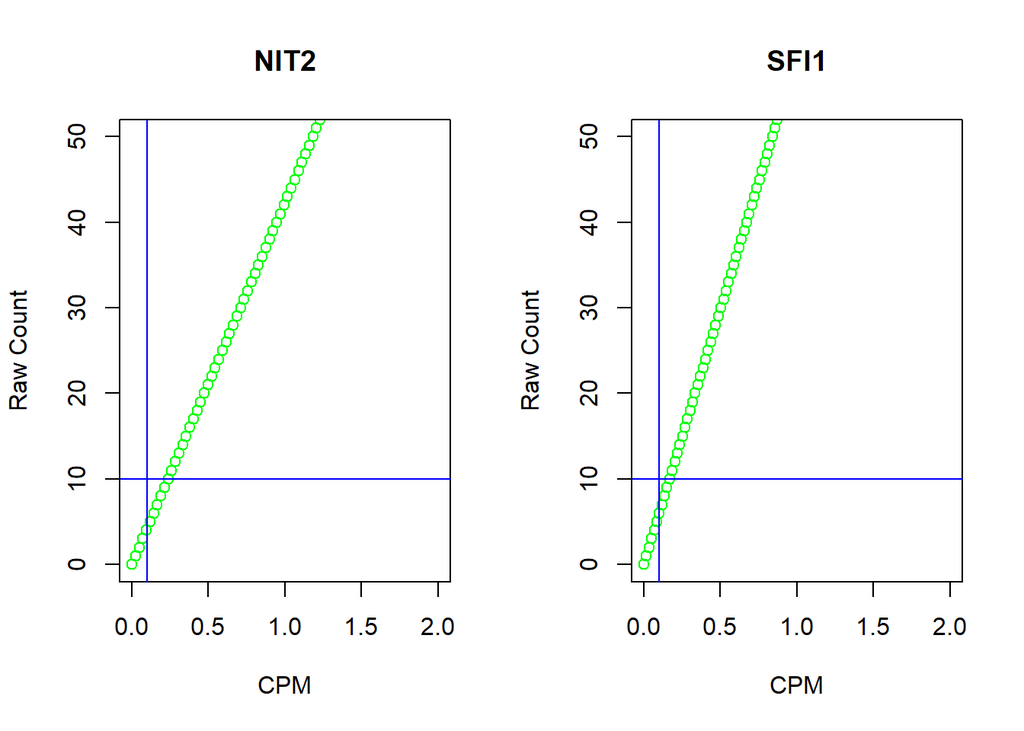

```r
par(mfrow=c(1,2))
plot(myCPM[,2],mydata$NIT2, xlab="CPM", ylab="Raw Count", main=colnames(myCPM)[2],
     ylim=c(0,50), xlim=c(0,2), col="green")
abline(v=0.1, h=10,col="blue")
plot(myCPM[,11],mydata$SFI1, xlab="CPM", ylab="Raw Count", main=colnames(myCPM)[11],
     ylim=c(0,50), xlim=c(0,2), col="green")
abline(v=0.1, h=10,col="blue")
```

Els gens amb un valor CPM inferior a un determinat cutoff es considera que és molt baix, cosa que indica que el gen associat no s’expressa en aquesta mostra. Els llindars de CPM més petits solen ser adequats per a biblioteques més grans.

## 3.2. Conversió a DGEList.

A continuació, crearem un objecte *DGEList*. Aquest és un objecte utilitzat per *edgeR* per emmagatzemar dades de recompte. Disposa de diversos “slots” (ranures) per emmagatzemar diversos paràmetres sobre les dades.La informació sobre la mida de la biblioteca es desa a la ranura mostral.

```r
dgeObj <- DGEList(counts.keep)
dgeObj
```

```
## An object of class "DGEList"
## $counts
##   NIT1 NIT2 NIT3 NIT4 NIT5 NIT6 NIT7 NIT8 NIT9 NIT10 SFI1 SFI2 SFI3 SFI4 SFI5
## 1    7    1    0    1    3    2    0    1    2    17    1    0    3    2    9
## 2  401  768  719  481  781 1517  629  720  542   484 1164  633  426  679  302
## 3    4    0    1    0    0    0    1    0    1    10    2    2    1    2    4
## 4    2    1    1    1    2    0    1    1    0     7    2    1    1    4    2
## 5    6   10    3   10    1    5    8    4    6     4   19   14    5    0   10
##   SFI6 SFI7 SFI8 SFI9 SFI10 ELI1 ELI2 ELI3 ELI4 ELI5 ELI6 ELI7 ELI8 ELI9 ELI10
## 1    3    2    1    3     2    3    0    1    3    3    4    5    1    1     0
## 2 1704  491  874  533   457 1301 1002  474  134  979 1325  489 1472  775   834
## 3    1    2    8    1     1    1    1    1    1    3    1    1    1    2     1
## 4    1    0    2    0     2    0    0    0    2    2    0    3    0    0     1
## 5    5    7    4    0     9    5   15    3    3    4    4    7   38   10     6
## 29588 more rows ...
##
## $samples
##      group lib.size norm.factors
## NIT1     1 66150219            1
## NIT2     1 42266701            1
## NIT3     1 50694521            1
## NIT4     1 47489104            1
## NIT5     1 60977255            1
## 25 more rows ...
```

## 3.3. Control de qualitat

Anema a comprovar que les dades són de bona qualitat i que les mostres són com esperaríem.

### Mida de la llibreria.

Primer, podem comprovar quantes lectures tenim per a cada mostra del dgeObj.

```r
dgeObj$samples
```

```
##       group lib.size norm.factors
## NIT1      1 66150219            1
## NIT2      1 42266701            1
## NIT3      1 50694521            1
## NIT4      1 47489104            1
## NIT5      1 60977255            1
## NIT6      1 46699715            1
## NIT7      1 41662275            1
## NIT8      1 55893949            1
## NIT9      1 39639702            1
## NIT10     1 69802989            1
## SFI1      1 59529266            1
## SFI2      1 68482369            1
## SFI3      1 51872996            1
## SFI4      1 40855745            1
## SFI5      1 39858001            1
## SFI6      1 84713691            1
## SFI7      1 45883365            1
## SFI8      1 53124121            1
## SFI9      1 44340733            1
## SFI10     1 55878027            1
## ELI1      1 51970092            1
## ELI2      1 61440249            1
## ELI3      1 52193544            1
## ELI4      1 15481426            1
## ELI5      1 85620372            1
## ELI6      1 73979605            1
## ELI7      1 64433651            1
## ELI8      1 81214046            1
## ELI9      1 64698354            1
## ELI10     1 42006161            1
```

```r
#dgeObj$samples$lib.size
#dgeObj$samples[,2]
#dgeObj$samples[,"lib.size"]
```

Podem fer una gràfica de barres per veure amb més facilitat si hi ha discrepàncies importants entre les mostres.

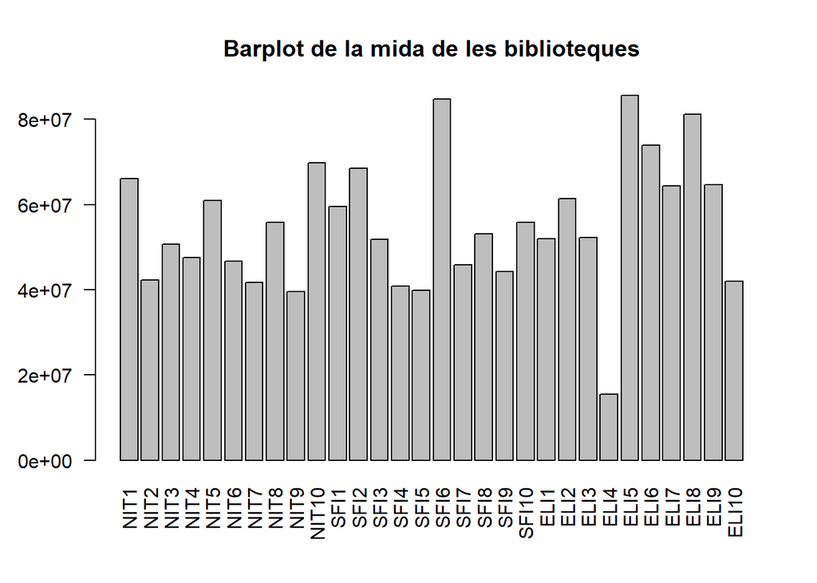

```r
barplot(dgeObj$samples$lib.size, names=colnames(dgeObj), las=2)
title("Barplot de la mida de les biblioteques")
```

### Boxplots.

Les dades de recompte no es distribueixen normalment. Utilitzarem boxplots per comprovar la distribució dels recomptes a l’escala log2. Podem utilitzar la funció cpm per obtenir recomptes de log2 per milió, que es corregeixen per a les diferents mides de la biblioteca. La funció de cpm també afegeix una petita compensació per evitar tenir registre de zero.

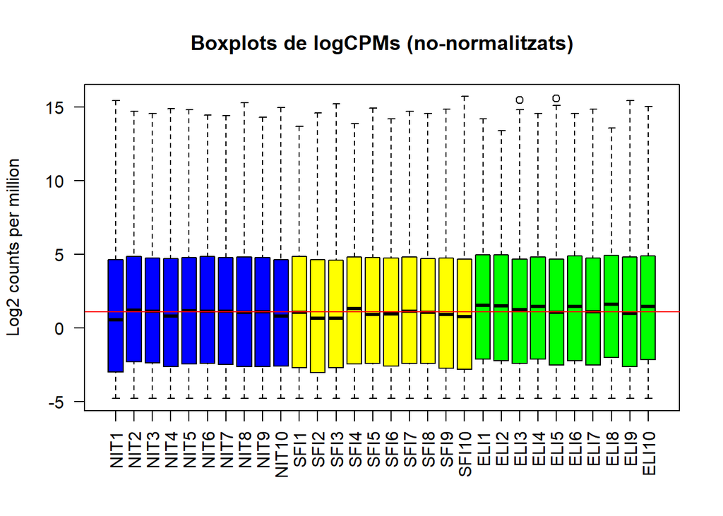

```r
logcounts <- cpm(dgeObj,log=TRUE)
boxplot(logcounts, xlab="", ylab="Log2 counts per million",las=2, col=c(rep("blue",10), rep("yellow",10),rep("green",10)))
abline(h=median(logcounts),col="red")
title("Boxplots de logCPMs (no-normalitzats)")
```

Observem que les distribucions no són idèntiques però la mitjana s´ajusta bastant a la linia vermella, que correspòn a la mitjana de logCPM.

### Gràfiques d’escalació multidimensional (MDS).

Una MDSplot és una visualització d’un PCA (anàlisi de components principals), que determina les majors fonts de variació de les dades. Un PCA és un exemple d’anàlisi no supervisada, en què no cal especificar els grups. Si el nostre experiment està ben controlat i ha funcionat bé, el que esperem veure és que les fonts més grans de variació de les dades són els tractaments/grups que ens interessen. També és una eina molt útil per controlar la qualitat i comprovar els outliers.

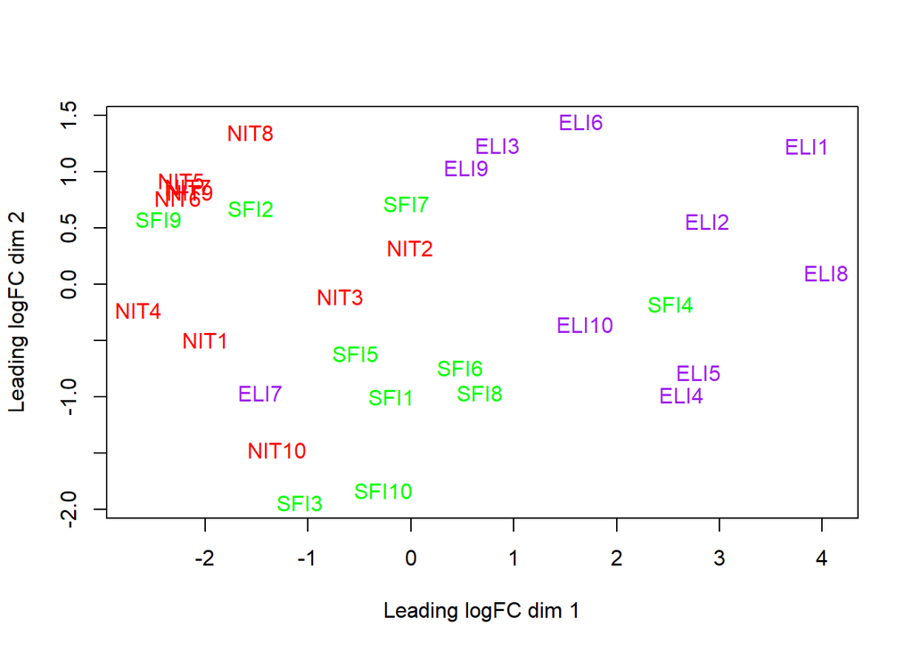

```r
plotMDS(dgeObj, col=col.cell)
```

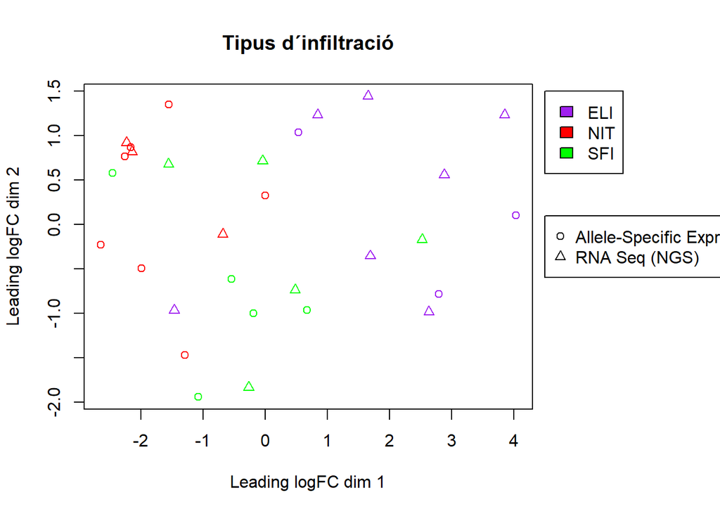

```r
par(xpd= T, mar = par()$mar + c(0,0,0,7))
plotMDS(dgeObj,col=col.cell,pch =c(1,2)[mol.type])
legend( 4.5,1.5,fill=c("purple","red","green"),legend=levels(group))
legend(4.5,0.1, legend= levels(mol.type),pch=c(1,2))
title("Tipus d´infiltració")
```

```r
par(mar=c(5, 4, 4, 2) + 0.1)
```

L’agrupament a la gràfica MDS es pot utilitzar per motivar canvis a la matriu de disseny a la llum dels possibles efectes del lot. Per exemple, si la primera rèplica de cada grup es va preparar en un moment diferent de la segona rèplica. Si la gràfica MDS mostrava la separació de les mostres per temps, pot valdre la pena incloure temps a l’anàlisi del flux descendent per tenir en compte l’efecte basat en el temps.

plotMDS traça de manera predeterminada les dues primeres dimensions, però podem graficar d´altres:

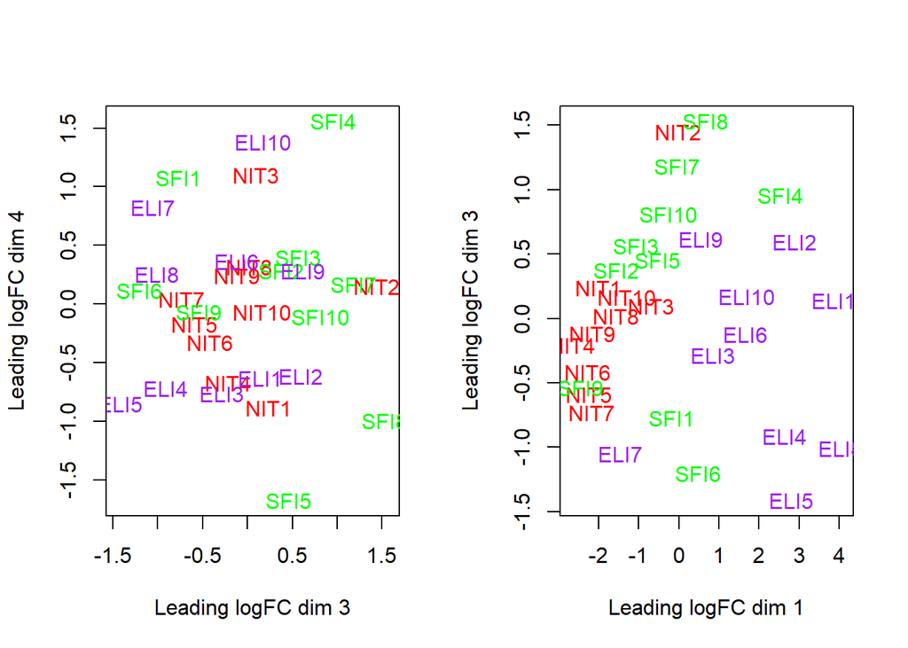

```r
par(mfrow=c(1,2))
plotMDS(dgeObj,dim=c(3,4), col=col.cell)
plotMDS(dgeObj,dim=c(1,3), col=col.cell)
```

Una altra alternativa és fer una gràfica MDS interactiva mitjançant el paquet Glimma. Això ens permet explorar de forma interactiva les diferents dimensions. Glimma es va crear per fer versions interactives d’alguns dels gràfics més populars del paquet limma. Actualment, es pot utilitzar per obtenir gràfiques MDS i gràfics MD. La sortida de glMDSPlot és una pàgina html (/mds/MDS-Plot.html) que mostra la trama MDS a l’esquerra i la quantitat de variació explicada per cada dimensió en una barra de bar a la dreta. L’usuari pot passar per punts per obtenir informació de mostra i canviar entre les dimensions successives de la trama MDS fent clic a les barres de la barra de comandament. Les gràfiques MDS predeterminades mostren les dimensions 1 i 2.

```r
labels <- paste(targets2$Sample_Name, group, mol.type)
group <- paste(group,mol.type,sep=".")
glMDSPlot(dgeObj, labels=labels, groups=group, folder="mds")
# html adjunt a la carpeta mds.
```

### Agrupació jeràrquica (clustering) amb heatmaps.

Seleccionem les dades dels 500 gens més variables i traçem el mapa de calor

```
##         1         2         3         4         5         6
## 0.6438267 0.3458818 0.3849616 0.3793817 0.8120733 2.3458088
```

```
## [1] "29028" "29559" "29562" "29545" "29546" "29528"
```

```
## [1] 500  30
```

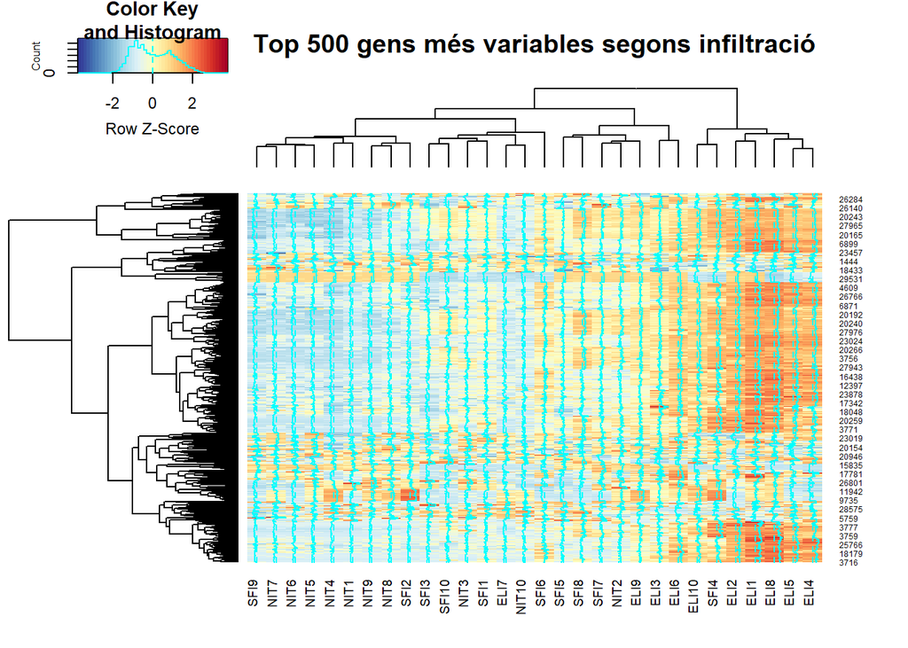

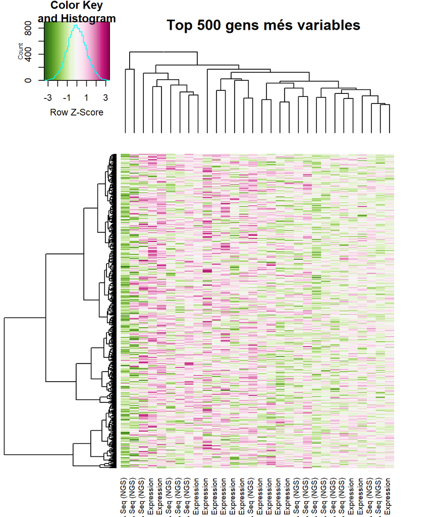

## 3.4. Normalització per biaix de composició.

El mètode TMM (trimmed mean of M-values normalization method) es realitza per eliminar els biaixos de composició entre biblioteques (Mark D Robinson i Oshlack 2010). Això genera un conjunt de factors de normalització, on el producte d’aquests factors i les mides de la biblioteca defineixen la mida efectiva de la biblioteca.

La funció calcNormFactors en edgeR calcula els factors de normalització entre llibreries. TMM, i la major part dels mètodes de normalització, escalen en realció d una mostra. Això actualitzarà els factors de normalització de l’objecte DGEList (els seus valors per defecte són 1). Mirem els factors de normalització d’aquestes mostres:

```r
dgeObj <- calcNormFactors(dgeObj)
head(dgeObj$samples)
```

```
##      group lib.size norm.factors
## NIT1     1 66150219    0.8516386
## NIT2     1 42266701    1.0908100
## NIT3     1 50694521    1.0170699
## NIT4     1 47489104    0.9616483
## NIT5     1 60977255    1.0467420
## NIT6     1 46699715    1.0779419
```

```r
sort(dgeObj$samples$norm.factors, decreasing = T)
```

```
##  [1] 1.1075602 1.0980930 1.0952598 1.0918830 1.0908100 1.0810463 1.0779419
##  [8] 1.0756108 1.0467420 1.0379452 1.0346108 1.0325596 1.0245074 1.0170699
## [15] 1.0092566 1.0049938 0.9989586 0.9987070 0.9971926 0.9912672 0.9893356
## [22] 0.9788644 0.9616483 0.9388134 0.9159077 0.9079877 0.8982797 0.8913085
## [29] 0.8516386 0.8384465
```

Els factors de normalització multipliquen per unificar totes les llibreries. Un factor de normalització inferior a 1 indica que es reduirà la mida de la biblioteca, ja que hi ha més supressió (és a dir, biaix de composició) respecte a les altres biblioteques. Això equival a escalar els recomptes cap amunt en aquesta mostra. Per contra, un factor superior a 1 augmentarà de mida de la biblioteca i equivaldrà a reduir els recomptes.

SF2 i NIT1 presenten els factors de normalització menors, i els més grans són ELI2 i ELI10.Si traçem la diferència mitjana mitjançant la funció plotMD per a aquestes mostres, hauríem de ser capaços de veure el problema de biaix de la composició. Utilitzarem els “logcounts”, que s’han normalitzat per la mida de la biblioteca, però no per al biaix de composició.

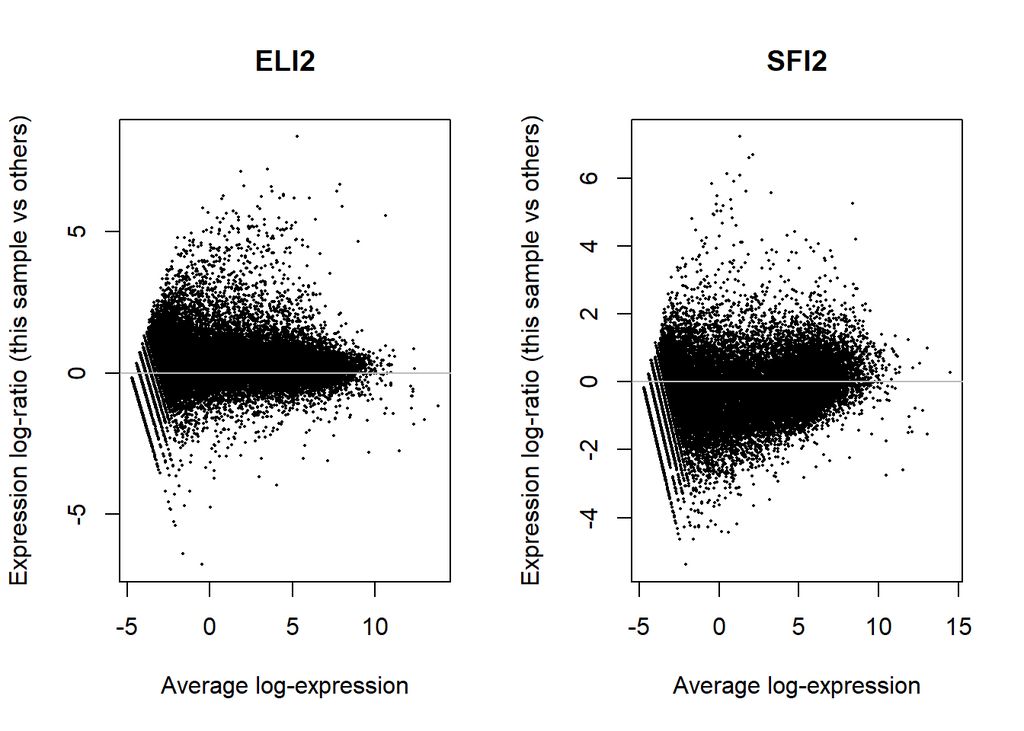

```r
par(mfrow=c(1,2))
plotMD(logcounts,column = 22)
abline(h=0,col="grey")
plotMD(logcounts,column = 12)
abline(h=0,col="grey")
```

Les gràfiques MD mostren una expressió mitjana (mitjana: eix x) contra canvis *log-fold* (diferència: eix y). Com que la nostra DGEList conté els factors de normalització, si féssim aquestes gràfiques mitjançant dgeObj, hauríem de veure que s’ha resolt el problema de biaix de composició.

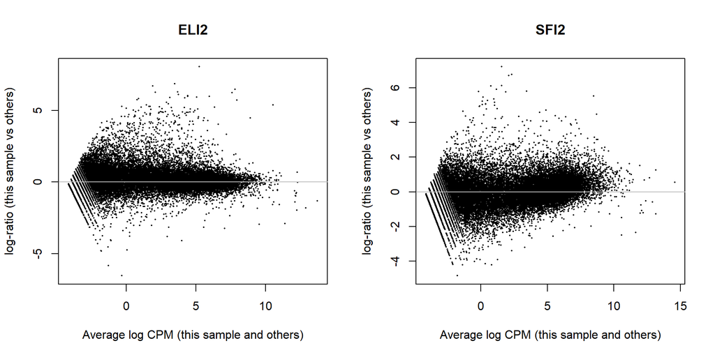

```r
par(mfrow=c(1,2))
plotMD(dgeObj,column = 22)
abline(h=0,col="grey")
plotMD(dgeObj,column = 12)
abline(h=0,col="grey")
```

# 4. Anàlisi de l´expressió diferencial.

## 4.1. Exploració de dades.

Una gràfica MDS mostra distàncies, en termes de coeficient biològic de variació (BCV), entre mostres.Ens dóna informació sobre la qualitat de les dades.

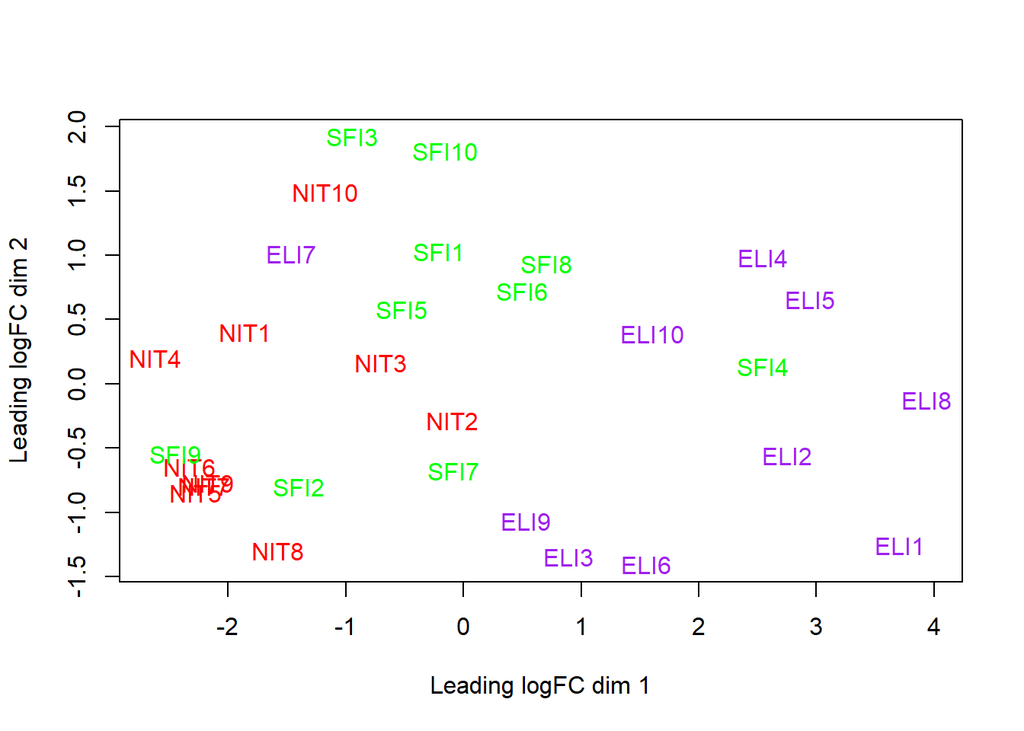

```r
plotMDS(dgeObj,col=col.cell)
```

## 4.2. Estimació de la dispersió.

El primer pas important en l’anàlisi de dades de DGE és estimar el paràmetre de dispersió de cada gen, una mesura del grau de variació “interbibliotecària” per a aquest gen. L’estimació de la dispersió comuna dóna una idea de la variabilitat global a través del genoma d’aquest conjunt de dades, promediada per a tots els gens:

```r
d1 <- estimateCommonDisp(dgeObj, verbose = T)
```

```
## Disp = 0.34592 , BCV = 0.5882
```

Per a l’anàlisi d’expressions diferencials rutinàries, s’utilitzen dispersions empíriques bayesianes amb etiquetes. Cal estimar la dispersió comuna abans d’estimar les dispersions amb les etiquetes.

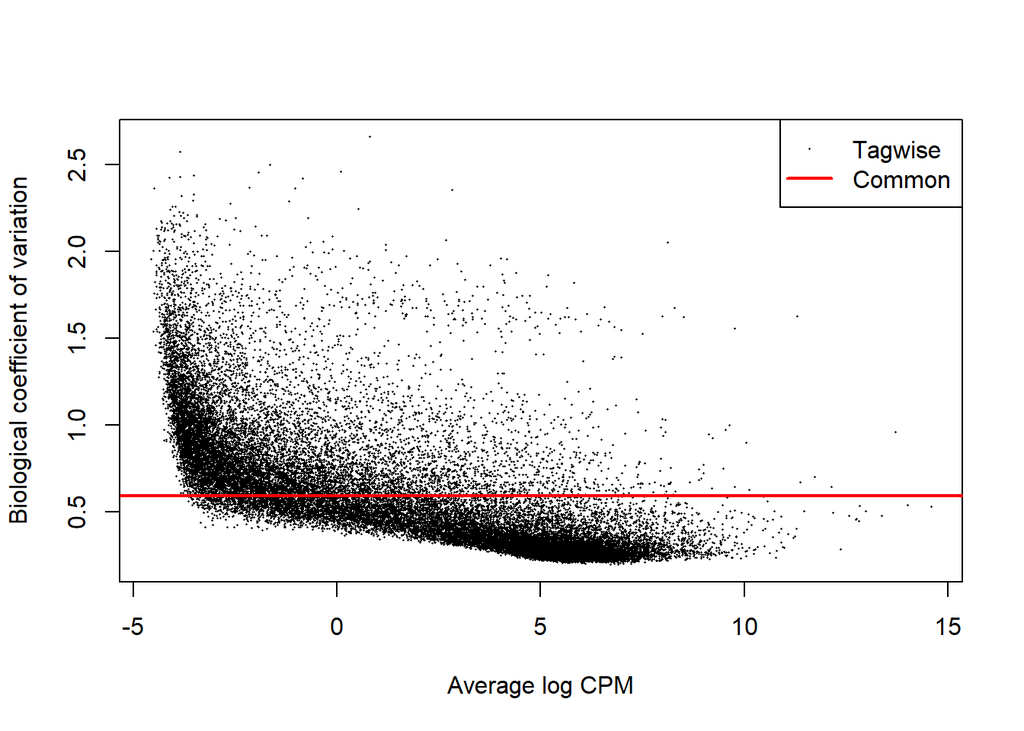

```r
d1 <- estimateTagwiseDisp(d1)
plotBCV(d1)
```

### Estimacions de dispersió GLM.

Per encaixar un model a edgeR hem de seguir diversos passos. En primer lloc, cal adaptar-se a la dispersió comuna. Després cal adaptar-se a un model de tendència (si no s’adapta a una tendència, el valor per defecte és utilitzar la dispersió comuna com a tendència). A continuació, podem encaixar la dispersió en etiquetes, que és una funció d’aquest model.

A més del dispersió comú i sense etiquetes, també podem estimar un model lineal generalitzat (glm) adequat amb edgeR. A continuació, farem estimacions de dispersió genètiques, permetent una possible tendència amb la mida del recompte de mitjanes. plotBCV() traça el coeficient biològic de variació (arrel quadrada de les dispersions) contra log2-CPM:

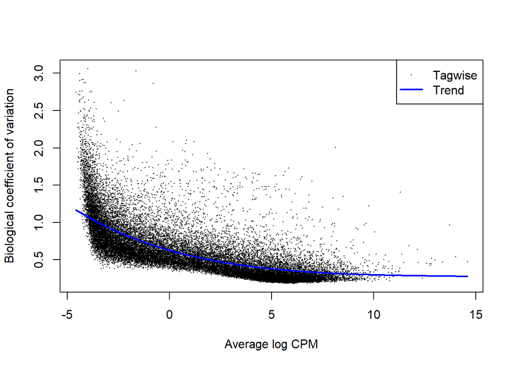

```r
dgeObj$samples$group=c(rep("1",10),rep("2",10),rep("3",10))
design.mat <- model.matrix(~ 0 + dgeObj$samples$group)
colnames(design.mat) <- levels(dgeObj$samples$group)
d2 <- estimateGLMCommonDisp(dgeObj,design.mat)
d2 <- estimateGLMTrendedDisp(dgeObj,design.mat, method="power")
# Es pot canviar el "method" a "auto", "bin.spline", "power", "spline", "bin.loess".
# El mètode per defecte es "auto" que fa servir "bin.spline" per >200 etiquetes, i "power" en els altres casos.
d2 <- estimateGLMTagwiseDisp(d2,design.mat)
plotBCV(d2)
```

### Comparació dels models en DESeq i edgeR.

Segons quin model fem servir s´obtenen diferents resultats. A la gràfica tenim dispersió a l´eix vertical, en comptes del BCV.

```r
cds <- newCountDataSet(data.frame(dgeObj$counts), dgeObj$samples$group)
cds <- estimateSizeFactors( cds )
sizeFactors( cds )
```

```
##      NIT1      NIT2      NIT3      NIT4      NIT5      NIT6      NIT7      NIT8
## 1.0773554 0.8667826 0.9688980 0.8700072 1.2195433 0.9448486 0.8106776 1.0626963
##      NIT9     NIT10      SFI1      SFI2      SFI3      SFI4      SFI5      SFI6
## 0.7693047 1.1915316 1.1666598 1.0926211 0.8842804 0.7695018 0.7505160 1.6004116
##      SFI7      SFI8      SFI9     SFI10      ELI1      ELI2      ELI3      ELI4
## 0.8980956 0.9871033 0.8325594 0.9733940 1.0667781 1.3229728 0.9316612 0.3036155
##      ELI5      ELI6      ELI7      ELI8      ELI9     ELI10
## 1.4690830 1.5358734 1.2381607 1.6835642 1.2218092 0.8802889
```

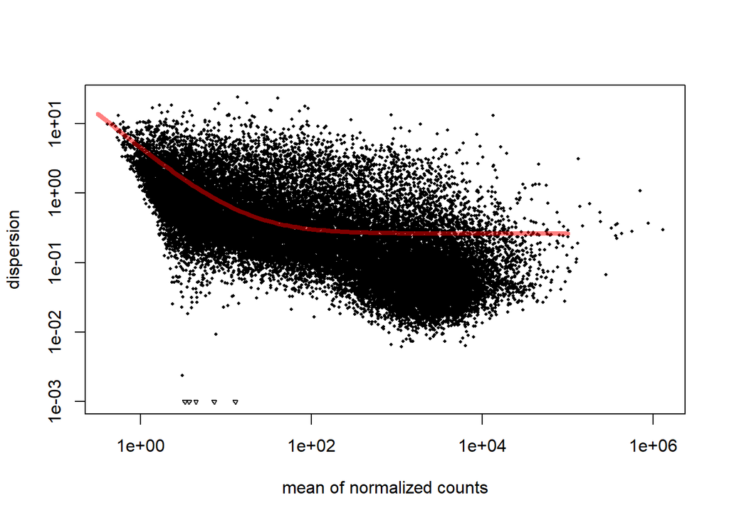

```r
cds <- estimateDispersions( cds , method="blind")
plotDispEsts(cds)
```

### Dispersió i variació biològica.

La dispersió d’un gen és simplement una altra mesura de la variància d’un gen i és usat per DESeq per modelar la variància global dels valors de recompte d’un gen. El model per a la variància (v ) dels valors de recompte utilitzat per DESeq és:

[v = s mu + alpha s ^ 2 mu ^ 2 text {On} alpha text {és la dispersió,} mu text {és el valor de recompte normalitzat previst i} s text { és el factor de mida} ]

La dispersió es pot interpretar com el quadrat del coeficient de variació biològica (per exemple, la diferència de recomptes entre dues rèpliques biològiques és del 40%, de manera que la dispersió del gen és (0,4 ^ 2 = 0,16 )).

## 4.3. Expressió diferencial.

La funció exactTest() fa servir el test binomial negatiu. La funció topTags() mostra convenientment els resultats més significatius. Per defecte, s’utilitza l’algoritme de Benjamini i Hochberg per controlar la taxa de descobriment falsa (FDR).

```r
d1$samples$group=c(rep("1",10),rep("2",10),rep("3",10))
d2$samples$group=c(rep("1",10),rep("2",10),rep("3",10))

et12 <- exactTest(d1, pair=c(1,2)) # compara grups 1 i 2, NIT-SFI
et13 <- exactTest(d1, pair=c(1,3)) # compara grups 1 i 3, NIT-ELI
et23 <- exactTest(d1, pair=c(2,3)) # compara grups 2 i 3, SFI-ELI
topTags(et12, n=10)
```

```
## Comparison of groups:  2-1
##          logFC      logCPM       PValue       FDR
## 3771  7.950778 -0.04405858 9.884292e-06 0.2925058
## 27983 5.915688  4.73306210 3.633153e-05 0.4780336
## 20189 5.386518  4.20474549 6.593965e-05 0.4780336
## 1887  3.581459  0.54417147 1.132363e-04 0.4780336
## 20192 5.991051  4.39823420 1.174725e-04 0.4780336
## 20272 6.021113 -2.60027976 1.477671e-04 0.4780336
## 3759  5.971675 -0.53233877 1.526265e-04 0.4780336
## 14323 2.078259  5.18198115 1.907459e-04 0.4780336
## 27981 4.689037 -1.40146245 2.061982e-04 0.4780336
## 3754  5.474625 -0.30014233 2.130449e-04 0.4780336
```

El nombre total de gens diferencialment expressats:

```r
de1 <- decideTestsDGE(et12, adjust.method="BH", p.value=0.05)
de2 <- decideTestsDGE(et13, adjust.method="BH", p.value=0.05)
de3 <- decideTestsDGE(et23, adjust.method="BH", p.value=0.05)

summary(de1);summary(de2);summary(de3)
```

```
##          2-1
## Down       0
## NotSig 29593
## Up         0
```

```
##          3-1
## Down     183
## NotSig 27708
## Up      1702
```

```
##          3-2
## Down       0
## NotSig 29593
## Up         0
```

Clarament, les diferències més grans es troben entre els grups NIT i ELI, és a dir, entre no-infiltr. i extensament-infiltr. La funció plotSmear genera una gràfica dels canvis log-fold/log-cpm (anàlogament a una gràfica MA per a les dades de microarray):

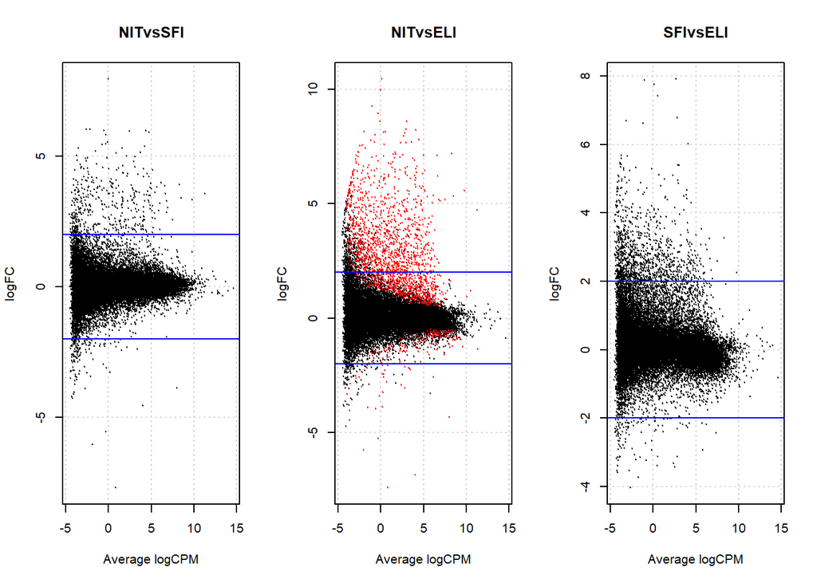

```r
par(mfrow=c(1,3))
de1tags12 <- rownames(d2)[as.logical(de1)]
plotSmear(et12, de.tags=de1tags12, main="NITvsSFI")
abline(h = c(-2, 2), col = "blue")

de1tags13 <- rownames(d2)[as.logical(de2)]
plotSmear(et13, de.tags=de1tags13, main="NITvsELI")
abline(h = c(-2, 2), col = "blue")

de1tags23 <- rownames(d2)[as.logical(de3)]
plotSmear(et23, de.tags=de1tags23, main="SFIvsELI")
abline(h = c(-2, 2), col = "blue")
```

## 4.4. GLM (model lineal generalitzat) per l´expressió diferencial.

El fem servir per trobar les etiquetes que ens interessen fent servir un criteri de verosimil.litud. Primer hem de crear una matriu de disseny per als grups. El principal supòsit aquí és que no influeix si les dades son NGS o “allele-specific expression”.

```r
gr<-as.character(group)

#Comparem únicament les diferències entres els grups d´infiltració:
design.mat<-model.matrix(~0+dgeObj$samples$group)
design.mat
```

```
##    dgeObj$samples$group1 dgeObj$samples$group2 dgeObj$samples$group3
## 1                      1                     0                     0
## 2                      1                     0                     0
## 3                      1                     0                     0
## 4                      1                     0                     0
## 5                      1                     0                     0
## 6                      1                     0                     0
## 7                      1                     0                     0
## 8                      1                     0                     0
## 9                      1                     0                     0
## 10                     1                     0                     0
## 11                     0                     1                     0
## 12                     0                     1                     0
## 13                     0                     1                     0
## 14                     0                     1                     0
```

[output cut: 21 more lines]

i ajustem el model lineal:

```r
fit <- glmFit(d2, design.mat)
head(fit$coefficients)
```

```
##   dgeObj$samples$group1 dgeObj$samples$group2 dgeObj$samples$group3
## 1             -16.57729             -16.69095             -17.02392
## 2             -11.18269             -11.23623             -11.18399
## 3             -17.21399             -16.80708             -17.53255
## 4             -17.26695             -17.25040             -17.88730
## 5             -15.94646             -15.78131             -15.70993
## 6             -14.91212             -14.57350             -13.63929
```

```r
# si comparem (group 1 - group 2) amb 0, equival a comparar grups 1 i 2
lrt12 <- glmLRT(fit, contrast=c(1,-1,0))
lrt13 <- glmLRT(fit, contrast=c(1,0,-1))
lrt23 <- glmLRT(fit, contrast=c(0,1,-1))
topTags(lrt13, n=10)
```

```
## Coefficient:  1*dgeObj$samples$group1 -1*dgeObj$samples$group3
##           logFC   logCPM       LR       PValue          FDR
## 2575  -8.199498 4.112614 82.10500 1.290459e-19 3.818855e-15
## 13513 -8.578912 3.032973 73.07064 1.250915e-17 1.850917e-13
## 26344 -6.383307 2.897115 72.18033 1.964038e-17 1.937393e-13
## 23964 -4.195523 4.030810 70.51103 4.577001e-17 2.772690e-13
## 25072 -2.787472 4.904747 70.46515 4.684705e-17 2.772690e-13
## 22733 -6.130417 4.118076 68.39069 1.341093e-16 6.614492e-13
## 2589  -3.866736 4.547101 67.77189 1.835481e-16 6.998610e-13
## 26284 -4.103448 5.579461 67.65197 1.950581e-16 6.998610e-13
## 18177 -7.008368 2.218148 67.47990 2.128459e-16 6.998610e-13
## 6871  -6.586971 3.083342 67.03655 2.665197e-16 7.887117e-13
```

i els gens més diferencialment expressats són:

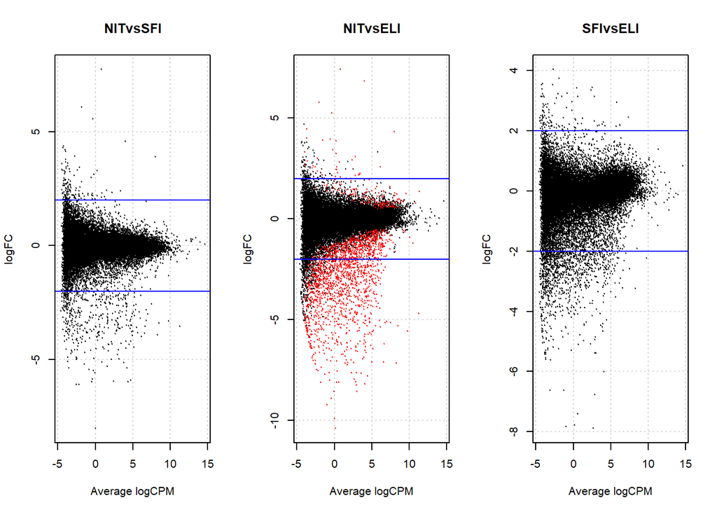

```r
par(mfrow=c(1,3))
dlr1 <- decideTestsDGE(lrt12, adjust.method="BH", p.value = 0.05)
dlrtags12 <- rownames(d2)[as.logical(de1)]
plotSmear(lrt12, de.tags=dlrtags12, main="NITvsSFI")
abline(h = c(-2, 2), col = "blue")

dlr2 <- decideTestsDGE(lrt13, adjust.method="BH", p.value = 0.05)
dlrtags13 <- rownames(d2)[as.logical(de2)]
plotSmear(lrt13, de.tags=dlrtags13, main="NITvsELI")
abline(h = c(-2, 2), col = "blue")

dlr3 <- decideTestsDGE(lrt23, adjust.method="BH", p.value = 0.05)
dlrtags23 <- rownames(d2)[as.logical(de3)]
plotSmear(lrt23, de.tags=dlrtags23, main="SFIvsELI")
abline(h = c(-2, 2), col = "blue")
```

Suposem ara que tenim dues variables, tipus d´infiltració i tipus mol.lecular. Només mostrarem els primers pasos d´aquest supòsit, ja que no ens interessen aquests resultats. El nostre anàlisi està basat en l´expressió diferencial entre els grups amb diferent grau d´infiltració.

```r
fit2 <- glmFit(d2, design)
head(coef(fit2))
```

```
##   (Intercept)   infiltrNIT  infiltrSFI typeRNA Seq (NGS)
## 1   -16.73590  0.236834041  0.19250759      -0.375518385
## 2   -11.17947 -0.001385718 -0.05346605      -0.006444031
## 3   -17.12988  0.050332105  0.59048250      -0.648394163
## 4   -17.89799  0.627301215  0.63960035       0.015512222
## 5   -15.44154 -0.401390447 -0.11258456      -0.451326011
## 6   -13.13348 -1.675709562 -1.28161514      -0.557938339
```

```r
lr <- glmLRT(fit2, coef=2)
topTags(lr)
```

```
## Coefficient:  infiltrNIT
##           logFC   logCPM       LR       PValue          FDR
## 2575  -8.187520 4.112614 81.84539 1.471595e-19 4.354891e-15
## 13513 -8.488006 3.032973 70.44447 4.734070e-17 7.004767e-13
## 22733 -6.241087 4.118076 67.64700 1.955502e-16 1.727876e-12
## 26344 -6.215525 2.897115 67.28321 2.351758e-16 1.727876e-12
## 25072 -2.789816 4.904747 66.85696 2.919399e-16 1.727876e-12
## 23964 -4.112775 4.030810 66.01240 4.480955e-16 2.210082e-12
## 2589  -3.846511 4.547101 65.66948 5.332532e-16 2.254366e-12
## 18177 -6.914430 2.218148 65.30000 6.432126e-16 2.379324e-12
## 23457 -4.533090 4.438357 64.96790 7.612822e-16 2.452487e-12
## 6871  -6.473664 3.083342 64.80060 8.287389e-16 2.452487e-12
```

```r
results<- as.data.frame(topTags(lrt13, n=Inf))
```

```r
summary(de <- decideTestsDGE(lrt13))
```

```
##        1*dgeObj$samples$group1 -1*dgeObj$samples$group3
## Down                                               2599
## NotSig                                            26419
## Up                                                  575
```

```r
summary(dlr2)
```

```
##        1*dgeObj$samples$group1 -1*dgeObj$samples$group3
## Down                                               2599
## NotSig                                            26419
## Up                                                  575
```

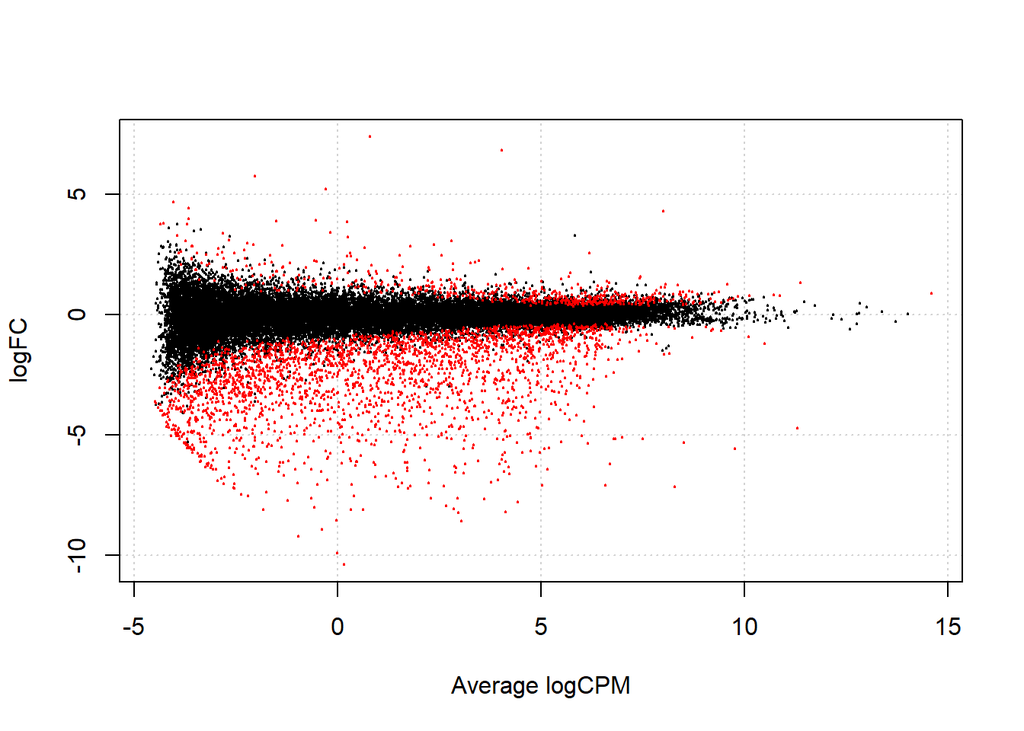

```r
detags <- rownames(d2)[as.logical(de)]
plotSmear(lrt13, de.tags=detags)
```

# 5. Annotació i visualització dels resultats.

## 5.1. Annotació de gens.

Ho farem mitjançant el paquet org.Mm.eg.db(), que és un dels diversos paquets *organism-level* que es reconstrueixen cada 6 mesos. Aquests paquets es mostren a la secció d’anotació de Bioconductor(http://bioconductor.org/packages/release/BiocViews.html#___AnnotationData). Un enfocament alternatiu és utilitzar biomaRt, una interfície del recurs BioMart.

```r
ann <- select(org.Mm.eg.db,keys=rownames(results),columns=c("ENTREZID","SYMBOL","GENENAME"))
ann[1:20,]
```

```
##    ENTREZID      SYMBOL                                          GENENAME
## 1      2575        <NA>                                              <NA>
## 2     13513        <NA>                                              <NA>
## 3     26344        <NA>                                              <NA>
## 4     23964       Tenm2                  teneurin transmembrane protein 2
## 5     25072        <NA>                                              <NA>
## 6     22733        <NA>                                              <NA>
## 7      2589        <NA>                                              <NA>
## 8     26284        <NA>                                              <NA>
## 9     18177        <NA>                                              <NA>
## 10     6871        <NA>                                              <NA>
## 11    25461        <NA>                                              <NA>
## 12     9578        <NA>                                              <NA>
## 13    12397 Cbfa2t2-ps1 CBFA2/RUNX1 translocation partner 2, pseudogene 1
## 14    25105        <NA>                                              <NA>
## 15    21879        <NA>                                              <NA>
## 16     2038        <NA>                                              <NA>
## 17    23457        <NA>                                              <NA>
## 18    13033        Ctsd                                       cathepsin D
## 19    17952       Naip6        NLR family, apoptosis inhibitory protein 6
## 20    22280        <NA>                                              <NA>
```

Es pot afegir l´anotació als resultats:

```r
results.annotated <- cbind(results, ann)
results.annotated[1:25,]
```

```
##           logFC    logCPM       LR       PValue          FDR ENTREZID
## 2575  -8.199498 4.1126145 82.10500 1.290459e-19 3.818855e-15     2575
## 13513 -8.578912 3.0329728 73.07064 1.250915e-17 1.850917e-13    13513
## 26344 -6.383307 2.8971150 72.18033 1.964038e-17 1.937393e-13    26344
## 23964 -4.195523 4.0308098 70.51103 4.577001e-17 2.772690e-13    23964
## 25072 -2.787472 4.9047466 70.46515 4.684705e-17 2.772690e-13    25072
## 22733 -6.130417 4.1180759 68.39069 1.341093e-16 6.614492e-13    22733
## 2589  -3.866736 4.5471013 67.77189 1.835481e-16 6.998610e-13     2589
## 26284 -4.103448 5.5794613 67.65197 1.950581e-16 6.998610e-13    26284
## 18177 -7.008368 2.2181480 67.47990 2.128459e-16 6.998610e-13    18177
## 6871  -6.586971 3.0833424 67.03655 2.665197e-16 7.887117e-13     6871
## 25461 -6.215675 3.9670932 66.76242 3.062813e-16 8.239802e-13    25461
## 9578  -5.159153 3.8989572 66.50618 3.487982e-16 8.601653e-13     9578
## 12397 -6.092660 0.3195155 66.32885 3.816309e-16 8.687388e-13    12397
## 25105 -6.308875 2.8566543 65.54861 5.669812e-16 1.198477e-12    25105
```

[output cut: 37 more lines]

```r
write.csv(results.annotated,file="NITvsELIResults.csv",row.names=FALSE)
```

Per decidir quins gens s’expressen de manera diferent, normalment prenem un tall de 0,05 sobre el valor p ajustat, NO el valor p brut. Això es deu al fet que estem provant més de 25000 gens i les probabilitats de trobar gens expressats de manera diferent són molt elevades quan fem moltes proves. Per tant, hem de controlar la taxa de descobriment fals(FDR), que és la columna de valor p ajustada a la taula de resultats. El que això significa és que si 100 gens són significatius a un percentatge de descobriment fals del 5%, estem disposats a acceptar que 5 seran falsos positius. La funció decideTests() mostra gens significatius al 5% de FDR.

## 5.2. Visualització dels resultats.

Podem fer un volcano plot per veure gràficament aquests gens més significatius:

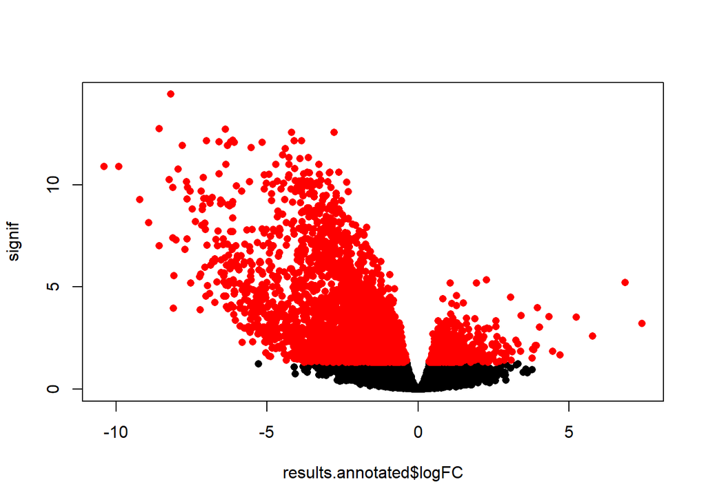

```r
signif <- -log10(results.annotated$FDR)
plot(results.annotated$logFC,signif,pch=16)
points(results.annotated[detags,"logFC"],-log10(results.annotated[detags,"FDR"]),pch=16,col="red")
```

Abans de fer un seguiment dels gens diferencialment expressats amb més treballs de laboratori, es recomana fer una revisió per comprovar els nivells d’expressió de les mostres individuals per als gens d’interès. Podem mirar ràpidament l’expressió agrupada mitjançant stripchart.

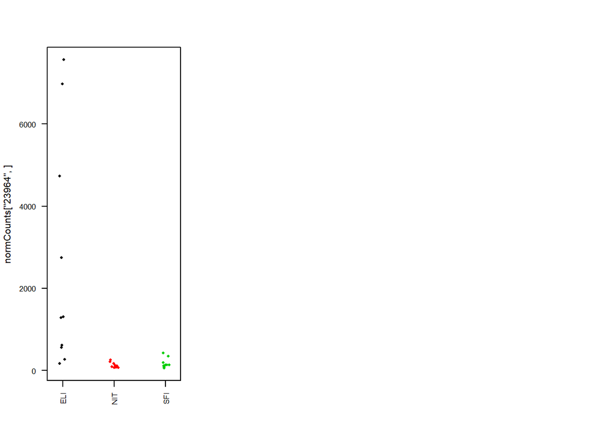

```r
library(RColorBrewer)
par(mfrow=c(1,3))
normCounts <- d2$counts
# Per al gen Tenm2:
stripchart(normCounts["23964",]~group,vertical=T,las=2,cex.axis=0.8,pch=16,col=1:6,method="jitter")
```

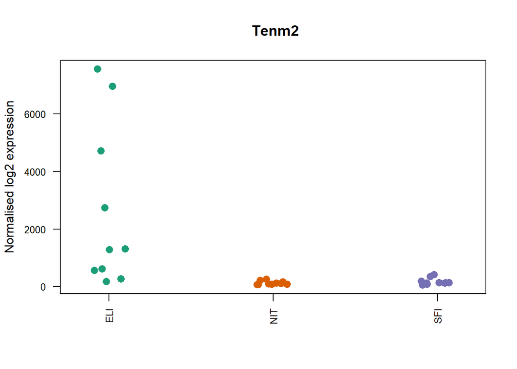

```r
nice.col <- brewer.pal(6,name="Dark2")
stripchart(normCounts["23964",]~group,vertical=TRUE,las=2,cex.axis=0.8,pch=16,cex=1.3,col=nice.col,method="jitter",ylab="Normalised log2 expression",main=" Tenm2")
```

## 5.3. Recuperació d´ubicacions genòmiques.

Volem recuperar les coordenades dels nostres gens més significatius. Com no sabem amb quin genoma estem treballant, primer provarem amb el genoma humà hg19:

```r
library(TxDb.Hsapiens.UCSC.hg19.knownGene)
tx<-TxDb.Hsapiens.UCSC.hg19.knownGene
keytypes(tx)
```

```
## [1] "CDSID"    "CDSNAME"  "EXONID"   "EXONNAME" "GENEID"   "TXID"     "TXNAME"
```

```r
#Prenem els 3 primers gens, Tenm2, Ctsd i Naip6:
keys <- c("23964","13033","17952")
#select(tx, keys=keys,
#       keytype = "GENEID",
#       columns=c("EXONCHROM","EXONSTART","EXONEND")
#      )
```

No obtenim cap resultat, provem doncs amb el genoma de ratolí mm10:

```r
library(TxDb.Mmusculus.UCSC.mm10.knownGene)
tx2 <- TxDb.Mmusculus.UCSC.mm10.knownGene
select(tx2, keys=keys,
       keytype = "GENEID",
       columns=c("EXONCHROM","EXONSTART","EXONEND")
      )
```

```
##    GENEID EXONCHROM EXONSTART   EXONEND
## 1   23964     chr11  37235837  37235882
## 2   23964     chr11  37145528  37145640
## 3   23964     chr11  36943941  36944241
## 4   23964     chr11  36864668  36864943
## 5   23964     chr11  36385119  36385328
## 6   23964     chr11  36300196  36300430
## 7   23964     chr11  36273231  36273469
## 8   23964     chr11  36221408  36221530
## 9   23964     chr11  36206905  36207110
## 10  23964     chr11  36171326  36171521
## 11  23964     chr11  36163719  36163820
## 12  23964     chr11  36147015  36147209
## 13  23964     chr11  36141483  36141683
## 14  23964     chr11  36139576  36139758
```

[output cut: 62 more lines]

## 5.4. Visió general de GenomicRanges.

GenomicRanges s´utilitza per manipular els intervals genòmics(https://www.ncbi.nlm.nih.gov/pmc/articles/PMC3738458/pdf/pcbi.1003118.pdf). Ens permet realitzar operacions comunes a intervals, com ara la superposició i el recompte. Podem definir la posició cromosòmica, inicial i final de cada regió.

```r
library(GenomicRanges)
chrs <- c("chr11", "chr13","chr7")
start <- c(36000000, 100000000, 142000000)
end <- c(37300000,101000000, 143000000)
my.ranges <- GRanges(rep(chrs,3),
                     IRanges(start=rep(start,each=3),
                             end = rep(end,each=3)))
my.ranges
```

```
## GRanges object with 9 ranges and 0 metadata columns:
##       seqnames              ranges strand
##          <Rle>           <IRanges>  <Rle>
##   [1]    chr11   36000000-37300000      *
##   [2]    chr13   36000000-37300000      *
##   [3]     chr7   36000000-37300000      *
##   [4]    chr11 100000000-101000000      *
##   [5]    chr13 100000000-101000000      *
##   [6]     chr7 100000000-101000000      *
##   [7]    chr11 142000000-143000000      *
##   [8]    chr13 142000000-143000000      *
##   [9]     chr7 142000000-143000000      *
##   -------
##   seqinfo: 3 sequences from an unspecified genome; no seqlengths
```

Hi ha diverses funcions útils per calcular les propietats de les dades. Més que per l’anàlisi d’ARN-seq, GenomicRanges s’utilitza a Bioconductor per a l’anàlisi de dades de NGS.

Per exemple, podem identificar regions sovint superposades entre dues GenomicRanges.

```r
genePos <- select(tx2, keys=keys,
       keytype = "GENEID",
       columns=c("EXONCHROM","EXONSTART","EXONEND")
      )
geneRanges <- GRanges(genePos$EXONCHROM, IRanges(genePos$EXONSTART,genePos$EXONEND), GENEID=genePos$GENEID)
geneRanges
```

```
## GRanges object with 76 ranges and 1 metadata column:
##        seqnames              ranges strand |      GENEID
##           <Rle>           <IRanges>  <Rle> | <character>
##    [1]    chr11   37235837-37235882      * |       23964
##    [2]    chr11   37145528-37145640      * |       23964
##    [3]    chr11   36943941-36944241      * |       23964
##    [4]    chr11   36864668-36864943      * |       23964
##    [5]    chr11   36385119-36385328      * |       23964
##    ...      ...                 ...    ... .         ...
##   [72]    chr13 100288101-100288187      * |       17952
##   [73]    chr13 100285677-100285841      * |       17952
##   [74]    chr13 100281121-100283913      * |       17952
##   [75]    chr13 100317612-100317674      * |       17952
##   [76]    chr13 100315984-100316675      * |       17952
##   -------
##   seqinfo: 3 sequences from an unspecified genome; no seqlengths
```

```r
findOverlaps(my.ranges,geneRanges)
```

```
## Hits object with 76 hits and 0 metadata columns:
##        queryHits subjectHits
##        <integer>   <integer>
##    [1]         1           1
##    [2]         1           2
##    [3]         1           3
##    [4]         1           4
##    [5]         1           5
##    ...       ...         ...
##   [72]         9          56
##   [73]         9          57
##   [74]         9          58
##   [75]         9          59
##   [76]         9          60
##   -------
##   queryLength: 9 / subjectLength: 76
```

```r
seqlevelsStyle(geneRanges)
```

```
## [1] "UCSC"
```

### Recuperació de les coordenades genètiques com a GenomicRanges.

La sortida de exonsBy és una llista d´exons:

```r
exo <- exonsBy(tx2,"gene")
exo
```

```
## GRangesList object of length 24594:
## $`100009600`
## GRanges object with 9 ranges and 2 metadata columns:
##       seqnames            ranges strand |   exon_id   exon_name
##          <Rle>         <IRanges>  <Rle> | <integer> <character>
##   [1]     chr9 21062393-21062717      - |    233853        <NA>
##   [2]     chr9 21062400-21062717      - |    233855        <NA>
##   [3]     chr9 21062894-21062987      - |    233856        <NA>
##   [4]     chr9 21063314-21063396      - |    233857        <NA>
##   [5]     chr9 21066024-21066377      - |    233858        <NA>
##   [6]     chr9 21066940-21067093      - |    233859        <NA>
##   [7]     chr9 21066940-21067925      - |    233860        <NA>
##   [8]     chr9 21068030-21068117      - |    233867        <NA>
##   [9]     chr9 21073075-21073096      - |    233869        <NA>
##   -------
##   seqinfo: 66 sequences (1 circular) from mm10 genome
##
## $`100009609`
## GRanges object with 8 ranges and 2 metadata columns:
##       seqnames            ranges strand |   exon_id   exon_name
##          <Rle>         <IRanges>  <Rle> | <integer> <character>
##   [1]     chr7 84935565-84941088      - |    190288        <NA>
##   [2]     chr7 84943141-84943264      - |    190289        <NA>
##   [3]     chr7 84943504-84943722      - |    190290        <NA>
##   [4]     chr7 84943504-84947000      - |    190291        <NA>
##   [5]     chr7 84946200-84947000      - |    190292        <NA>
##   [6]     chr7 84947372-84947651      - |    190293        <NA>
##   [7]     chr7 84948507-84949184      - |    190294        <NA>
##   [8]     chr7 84963816-84964115      - |    190295        <NA>
##   -------
##   seqinfo: 66 sequences (1 circular) from mm10 genome
##
## $`100009614`
## GRanges object with 1 range and 2 metadata columns:
##       seqnames            ranges strand |   exon_id   exon_name
##          <Rle>         <IRanges>  <Rle> | <integer> <character>
##   [1]    chr10 77711457-77712009      + |    250227        <NA>
##   -------
##   seqinfo: 66 sequences (1 circular) from mm10 genome
##
## ...
## <24591 more elements>
```

Per accedir a l’estructura d’un determinat gen, podem utilitzar la sintaxi [[]] amb el nom del gen (Entrez gen ID) entre cometes. Si volguéssim una regió sencera que abasta el gen, podríem utilitzar la funció range

```r
range(exo[["23964"]])
```

```
## GRanges object with 1 range and 0 metadata columns:
##       seqnames            ranges strand
##          <Rle>         <IRanges>  <Rle>
##   [1]    chr11 36006656-37235882      -
##   -------
##   seqinfo: 66 sequences (1 circular) from mm10 genome
```

# 6. Exportació de pistes.

També és possible guardar els resultats d’una anàlisi de bioconductors en un navegador per permetre l’anàlisi i la integració interactives amb altres tipus de dades o compartir amb col·laboradors. Per exemple, potser voldríem que una pista del navegador indiqui on es troben els nostres gens expressats de manera diferent. Utilitzarem el bedformat per mostrar aquestes ubicacions. Anotarem els intervals amb informació de la nostra anàlisi, com ara el canvi de plec i la importància.

Primer creem un marc de dades només per als gens DE.

```r
sigGenes <- results.annotated[detags,]
sigGenes[1:15,]
```

```
##          logFC      logCPM        LR       PValue          FDR ENTREZID SYMBOL
## 22   4.3301590  7.98272330 19.443684 1.036099e-05 2.914570e-04       22   <NA>
## 40  -2.5466636  0.33483956 17.866363 2.369729e-05 5.968288e-04       40   <NA>
## 44  -0.6657930  4.23499016  8.589671 3.380751e-03 3.524007e-02       44   <NA>
## 45  -1.6686439  1.12764638 15.370562 8.835412e-05 1.829716e-03       45   <NA>
## 46  -1.3137211 -0.06459686 13.559471 2.311222e-04 4.085782e-03       46   <NA>
## 57  -2.5182961 -2.06396284 23.719925 1.114230e-06 4.390598e-05       57   <NA>
## 62  -3.2719597  1.56920004 33.647753 6.605114e-09 5.282841e-07       62   <NA>
## 76  -1.5843594  2.04669876 14.565905 1.353414e-04 2.624611e-03       76   <NA>
## 89   0.9688761  6.81421533 10.428188 1.241064e-03 1.622926e-02       89   <NA>
## 137  1.5519076 -1.67692763  8.322496 3.915709e-03 3.937396e-02      137   <NA>
## 140 -0.9285109  0.95312010  8.662042 3.249070e-03 3.419265e-02      140   <NA>
## 143 -1.1865915 -1.52266034  9.264939 2.335823e-03 2.647415e-02      143   <NA>
## 144 -1.8568946 -0.59065283 24.615599 6.998295e-07 2.941769e-05      144   <NA>
## 150  0.5779696  5.90320119  9.216798 2.398046e-03 2.698984e-02      150   <NA>
```

[output cut: 17 more lines]

Fem la funció range() per obtenir un únic rang per a cada gen i tranformar-lo a un objecte més convenient.

```r
exoRanges <- unlist(range(exo))
sigRegions <- exoRanges[na.omit(match(sigGenes$ENTREZID, names(exoRanges)))]
sigRegions
```

```
## GRanges object with 641 ranges and 0 metadata columns:
##         seqnames              ranges strand
##            <Rle>           <IRanges>  <Rle>
##   11302    chr11 120007313-120047167      -
##   11409     chr5 115110299-115119346      -
##   11438     chr2 181018380-181043546      -
##   11535     chr7 110627661-110629820      +
##   11545     chr1 180568924-180601254      +
##     ...      ...                 ...    ...
##   28078    chr13   28142484-28151611      +
##   28105    chr18   46165300-46212607      -
##   28248     chr6 141907282-141946962      -
##   28250     chr6 141805440-141856199      -
##   28254     chr6 142085761-142208521      -
##   -------
##   seqinfo: 66 sequences (1 circular) from mm10 genome
```

En lloc de només representar les ubicacions genòmiques, el format .bed també és capaç de acolorir cada rang d’acord amb alguna propietat de l’anàlisi (per exemple, la direcció i la magnitud del canvi) per ajudar a ressaltar determinades regions d’interès. També es pot mostrar una puntuació quan es fa clic en una regió. Una utilitat útil de GenomicRanges és que podem adjuntar metadades a cada rang mitjançant la funció mcols. Les metadades es poden subministrar en forma de marc de dades.

```r
mcols(sigRegions) <- sigGenes[match(names(sigRegions), rownames(sigGenes)),]
sigRegions
```

```
## GRanges object with 641 ranges and 8 metadata columns:
##         seqnames              ranges strand |              logFC
##            <Rle>           <IRanges>  <Rle> |          <numeric>
##   11302    chr11 120007313-120047167      - |  0.817429530179723
##   11409     chr5 115110299-115119346      - | -0.669098428324545
##   11438     chr2 181018380-181043546      - |  0.910920109606485
##   11535     chr7 110627661-110629820      + |  -1.65442398063402
##   11545     chr1 180568924-180601254      + |  0.541591455513655
##     ...      ...                 ...    ... .                ...
##   28078    chr13   28142484-28151611      + | -0.548374279995536
##   28105    chr18   46165300-46212607      - | -0.790435228449426
##   28248     chr6 141907282-141946962      - |  -3.17291659902311
##   28250     chr6 141805440-141856199      - |  -1.30387240129358
##   28254     chr6 142085761-142208521      - |  -2.58934287496386
##                     logCPM               LR               PValue
```

[output cut: 40 more lines]

Les metadades que hem afegit també es poden utilitzar com a mitjà per interrogar els intervals; com si les dades estiguessin contingudes en un marc de dades.

```r
sigRegions[order(sigRegions$LR,decreasing = TRUE)]
```

```
## GRanges object with 641 ranges and 8 metadata columns:
##         seqnames              ranges strand |              logFC
##            <Rle>           <IRanges>  <Rle> |          <numeric>
##   23964    chr11   36006656-37235882      - |  -4.19552267953141
##   13033     chr7 142371096-142388038      - |   -4.4923740407502
##   17952    chr13 100281121-100317674      - |    -3.627654525912
##   17883    chr11   67078300-67102291      + |  -2.62239151914312
##   21935    chr16   11313812-11320074      + |   -3.2604938601378
##     ...      ...                 ...    ... .                ...
##   14396     chrX   72432681-72656848      - |   2.31077325179895
##   22635     chr5 137378637-137477064      - |  0.694257681183349
##   20130     chr7   45017961-45021647      + |  0.450382433245389
##   17973     chr9 100492293-100546134      - |   1.15038620980898
##   18811    chr13   12996125-13005383      - | -0.651711075221602
##                   logCPM               LR               PValue
```

[output cut: 40 more lines]

```r
Score <- -log10(sigRegions$FDR)
```

Ara crearem una puntuació a partir dels valors p que es mostraran a cada regió i l’esquema de colors per a les regions en funció del *fold-change*. Per a la puntuació podem utilitzar el $-log_{10}$ del valor p ajustat. A l’hora d’escollir paletes de colors, ens podem preocupar de que siguin adequades per a daltònics . L’esquema de colors vermell/verd aplicat tradicionalment als microarrays és una *mala* elecció.

```r
rbPal <-colorRampPalette(c("red", "blue"))
logfc <- pmax(sigRegions$logFC, -5)
logfc <- pmin(logfc , 5)
Col <- rbPal(10)[as.numeric(cut(logfc, breaks = 10))]
```

Els colors i la puntuació s’han de desar a GRanges com a score i itemRgb respectivament, i s’utilitzaran per construir la pista del navegador. Ara podem exportar els resultats significatius de l’anàlisi d´expressió diferencial com a .bed utilitzant rtracklayer. Es pot carregar el fitxer resultant a IGV.

```r
mcols(sigRegions)$score <- Score
mcols(sigRegions)$itemRgb <- Col
```

```r
library(rtracklayer)
export(sigRegions , con = "topHits.bed")
```

# 7. Proves de significació biològica competitives.

## 7.1. Anàlisi GOseq.

GOseq és un mètode per realitzar un anàlisi ontològic de gens, adequat per a dades de RNA-seq, ja que dóna compte del biaix de longitud del gen en la detecció de sobrerepresentació.

Primerament, GOseq ha de quantificar el biaix de longitud present al conjunt de dades a considerar. Això es fa calculant una funció de ponderació de probabilitats o PWF, que es pot pensar com una funció que dóna la probabilitat que un gen s’expressi diferencialment (DE), basat només en la seva longitud. El PWF es calcula ajustant una spline monotònica a la sèrie de dades binàries d’expressió diferencial (1 = DE, 0 = Not DE) en funció de la longitud del gen. El PWF s’utilitza per ponderar la possibilitat de seleccionar cada gen quan es formi una distribució nul·la per a membres de la categoria GO. El fet que el PWF es calculi directament a partir del conjunt de dades analitzat fa que aquest plantejament sigui robust, només corregint el biaix de longitud present a les dades. “L’anàlisi de GO de dades de RNA-seq requereix l’ús de mostreig aleatori per generar una distribució nula adequada per a membres de la categoria GO i calcular la importància de cada categoria per a la sobrerepresentació entre els gens DE. En la majoria dels casos, la distribució de Wallenius es pot utilitzar per aproximar la distribució nul real, sense cap pèrdua significativa de precisió. El paquet goseq implementa aquesta aproximació com a opció predeterminada.” (GOseq vignette)

Creem una llista de DEG:

```r
print(head(results))
```

```
##           logFC   logCPM       LR       PValue          FDR
## 2575  -8.199498 4.112614 82.10500 1.290459e-19 3.818855e-15
## 13513 -8.578912 3.032973 73.07064 1.250915e-17 1.850917e-13
## 26344 -6.383307 2.897115 72.18033 1.964038e-17 1.937393e-13
## 23964 -4.195523 4.030810 70.51103 4.577001e-17 2.772690e-13
## 25072 -2.787472 4.904747 70.46515 4.684705e-17 2.772690e-13
## 22733 -6.130417 4.118076 68.39069 1.341093e-16 6.614492e-13
```

```r
genes <- results$FDR < 0.01
names(genes) <- rownames(results)
print(head(genes))
```

```
##  2575 13513 26344 23964 25072 22733
##  TRUE  TRUE  TRUE  TRUE  TRUE  TRUE
```

Ajustem la PWF:

```r
library(goseq)
#print(supportedGeneIDs())
#print(supportedGenomes())
pwf <- nullp(genes, "mm10","knownGene")
```

```
## Can't find mm10/knownGene length data in genLenDataBase...
```

```
## Found the annotation package, TxDb.Mmusculus.UCSC.mm10.knownGene
```

```
## Trying to get the gene lengths from it.
```

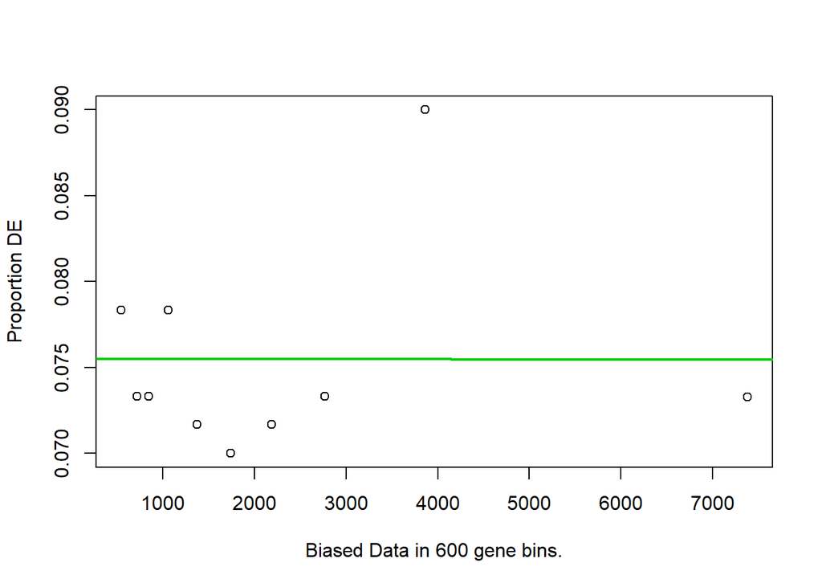

Fem l´anàlisis d’enriquiment (*Gen Enrichment Analysis*):

```r
go.results <- goseq(pwf, "mm10","knownGene")
```

```
## Fetching GO annotations...
```

```
## For 23861 genes, we could not find any categories. These genes will be excluded.
```

```
## To force their use, please run with use_genes_without_cat=TRUE (see documentation).
```

```
## This was the default behavior for version 1.15.1 and earlier.
```

```
## Calculating the p-values...
```

```r
go.results[1:15,]
```

```
##         category over_represented_pvalue under_represented_pvalue numDEInCat
## 1857  GO:0004725            1.870863e-10                1.0000000         20
## 1853  GO:0004721            1.332808e-07                1.0000000         20
## 5193  GO:0016791            1.915358e-06                0.9999995         22
## 2722  GO:0006470            9.026447e-06                0.9999975         22
## 357   GO:0001518            1.205973e-05                0.9999996          6
## 8134  GO:0034706            1.269845e-05                0.9999990          8
## 4978  GO:0016311            1.613900e-05                0.9999948         25
## 2194  GO:0005381            3.156255e-05                1.0000000          4
## 8315  GO:0035335            8.147587e-05                0.9999928          7
## 9219  GO:0042578            2.133884e-04                0.9999218         23
## 17735 GO:1904949            2.401036e-04                0.9999667          8
## 5667  GO:0019829            2.427022e-04                0.9999603          9
## 6074  GO:0022853            2.427022e-04                0.9999603          9
## 9244  GO:0042625            2.427022e-04                0.9999603          9
```

[output cut: 17 more lines]

## 7.2. FGSEA.

L’anàlisi d’enriquiment ràpid de conjunts genètics pre-consultats (GSEA) es realitza:

- classificant tots els gens del conjunt de dades segons la seva correlació amb el fenotip escollit,
- identificant les posicions de rang de tots els membres del conjunt de gens i
- calculant una puntuació d’enriquiment (ES) que representa la diferència entre els rànquings observats i el que s’esperaria suposant una distribució de rànquing aleatori.

“Després d’establir l’ES per a cada grup de gens a través del fenotip, GSEA reiteradament randomitza les etiquetes de les mostres i torna a fer l’enriquiment a través de les classes aleatòries. Mitjançant repetides randomitzacions d’etiquetes de classe, es pot comparar l’ES de cada conjunt de gens a través de les classes veritables amb la distribució ES de les classes aleatòries. Es consideren significatius aquells conjunts de gens que superen significativament les permutacions iteratives de classe aleatòria.” De fgsea[vignette] (http://www.bioconductor.org/packages/release/bioc/vignettes/fgsea/inst/doc/fgsea-tutorial.html) “fast preranked gene set enrichment analysis (GSEA)”.

```r
library(fgsea)
results.ord <- results[ order(-results[,"logFC"]), ]
head(results.ord)
```

```
##          logFC     logCPM        LR       PValue          FDR
## 5759  7.408705  0.7784657 17.778632 2.481546e-05 6.186721e-04
## 15835 6.847999  4.0177782 28.177392 1.106900e-07 6.037119e-06
## 24728 5.779873 -2.0480865 14.671822 1.279448e-04 2.512455e-03
## 23602 5.237948 -0.3027408 19.393131 1.063890e-05 2.984238e-04
## 27352 4.690643 -4.0458205  9.717483 1.825233e-03 2.184154e-02
## 20962 4.456888 -3.6843629 10.696537 1.073362e-03 1.438588e-02
```

```r
ranks <- results.ord$logFC
names(ranks) <- rownames(results.ord)
head(ranks)
```

```
##     5759    15835    24728    23602    27352    20962
## 7.408705 6.847999 5.779873 5.237948 4.690643 4.456888
```

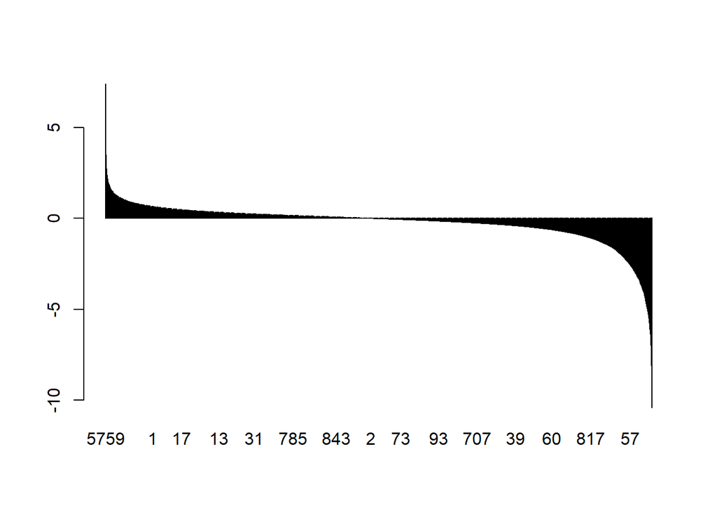

```r
barplot(ranks)
```

Carreguem les rutes:

```r
load("mouse_H_v5.rdata")
pathways <- Mm.H
```

Anàlisi de conducta:

```r
fgseaRes <- fgsea(pathways, ranks, minSize=15, maxSize = 500, nperm=1000)
fgseaRes[order(padj), ]
```

```
##                                        pathway        pval      padj         ES
##  1:           HALLMARK_CHOLESTEROL_HOMEOSTASIS 0.004439512 0.1370614 -0.6790700
##  2:         HALLMARK_UNFOLDED_PROTEIN_RESPONSE 0.005482456 0.1370614 -0.6613743
##  3: HALLMARK_EPITHELIAL_MESENCHYMAL_TRANSITION 0.010050251 0.1588983 -0.5115251
##  4:              HALLMARK_BILE_ACID_METABOLISM 0.012711864 0.1588983 -0.5808456
##  5:                   HALLMARK_APICAL_JUNCTION 0.116044400 0.5826626 -0.4683589
##  6:                        HALLMARK_COMPLEMENT 0.121334681 0.5826626 -0.4574610
##  7:                  HALLMARK_MTORC1_SIGNALING 0.121827411 0.5826626 -0.4696151
##  8:                    HALLMARK_MYC_TARGETS_V2 0.163145540 0.5826626 -0.5625417
##  9:                       HALLMARK_P53_PATHWAY 0.065989848 0.5826626 -0.4912743
## 10:                    HALLMARK_UV_RESPONSE_DN 0.097959184 0.5826626 -0.4875485
## 11:                        HALLMARK_PEROXISOME 0.149681529 0.5826626 -0.4961710
## 12:                   HALLMARK_SPERMATOGENESIS 0.145194274 0.5826626 -0.4721273
## 13:                 HALLMARK_KRAS_SIGNALING_DN 0.099694812 0.5826626 -0.4781859
## 14:               HALLMARK_PANCREAS_BETA_CELLS 0.159502262 0.5826626 -0.5476568
```

[output cut: 89 more lines]

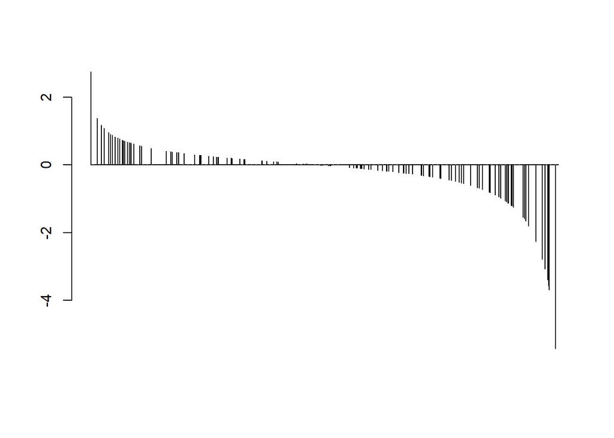

```r
tmpInd <- match(pathways[["HALLMARK_APOPTOSIS"]],names(ranks))
tmpInd <- tmpInd[!is.na(tmpInd)]
ranks2 <- rep(0,length(ranks))
ranks2[tmpInd] <- ranks[tmpInd]
barplot(ranks2)
```

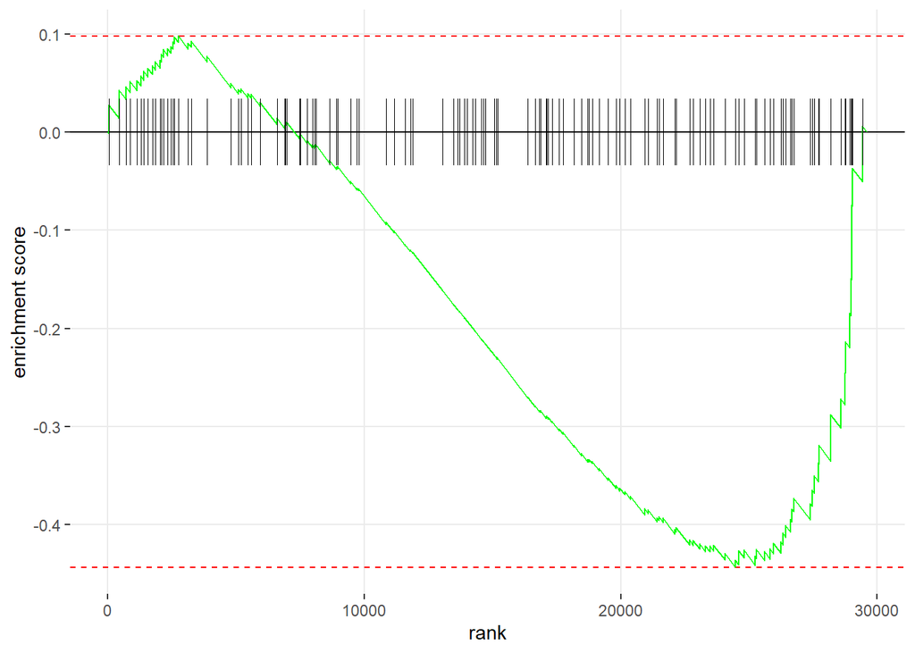

```r
plotEnrichment(pathways[["HALLMARK_APOPTOSIS"]],
               ranks)
```

[GSEA article](http://www.pnas.org/content/102/43/15545.full)

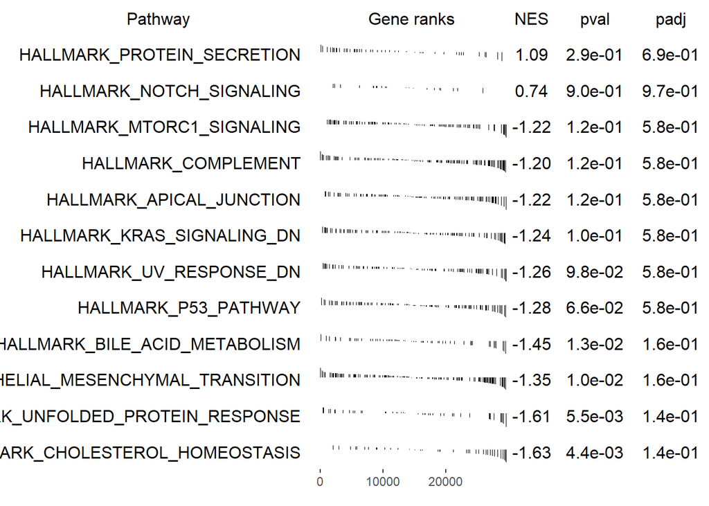

```r
topPathwaysUp <- fgseaRes[ES > 0][head(order(pval), n=10), pathway]
topPathwaysDown <- fgseaRes[ES < 0][head(order(pval), n=10), pathway]
topPathways <- c(topPathwaysUp, rev(topPathwaysDown))
plotGseaTable(pathways[topPathways], ranks, fgseaRes,
              gseaParam = 0.5)
```

## 7.3. CAMERA.

Altres bases de dades de conjunts de gens disponibles són procedents de la MSigDB del Broad Institute (Broad Institute’s Molecular Signatures Database ([MSigDB](http://software.broadinstitute.org/gsea/msigdb)). [CAMERA](https://academic.oup.com/nar/article/40/17/e133/2411151/Camera-a-competitive-gene-set-test-accounting-for)). CAMERA és una bona opció per contrastar un gran nombre de conjunts de gens, com els conjunts MSigDB, ja que és molt ràpid. Té l’avantatge de comptabilitzar la correlació intergènica de cada conjunt genètic (Wu i Smyth 2012) .

Aquí utilitzarem els conjunts de gens C2 per al ratolí, disponibles com a fitxers .rdata de la pàgina de bioinformàtica WEHI http://bioinf.wehi.edu.au/software/MSigDB/index.html . Els conjunts de gens C2 contenen 4725 conjunts genètics de diversos llocs: BioCarta, KEGG, Pathway Interaction Database, Reactome, així com alguns estudis publicats. No inclou termes GO.

```r
load("mouse_c2_v5.rdata")
names(Mm.c2)[1:5]
```

```
## [1] "KEGG_GLYCOLYSIS_GLUCONEOGENESIS"
## [2] "KEGG_CITRATE_CYCLE_TCA_CYCLE"
## [3] "KEGG_PENTOSE_PHOSPHATE_PATHWAY"
## [4] "KEGG_PENTOSE_AND_GLUCURONATE_INTERCONVERSIONS"
## [5] "KEGG_FRUCTOSE_AND_MANNOSE_METABOLISM"
```

```r
length(Mm.c2)
```

```
## [1] 4725
```

Els identificadors del gen són Entrez Gene ID. Hem d’assignar els ID del gen Entrez entre la llista de conjunts de gens i la nostra llista. Podem fer-ho mitjançant la funció ids2indices().

```r
c2.ind <- ids2indices(Mm.c2, rownames(d2$counts))
```

De manera predeterminada, CAMERA pot estimar la correlació per a cada conjunt de gens per separat. Tanmateix, a la pràctica, funciona bé per establir una petita correlació intergència d´aprox. 0,05 mitjançant l’ argument *inter.gene.cor*.

```r
gst.camera<- camera.DGEList(d2,index=c2.ind,design=design.mat,contrast=2,inter.gene.cor=0.05)
```

Obtenim un dataframe de l´estadístic resultant, on cada fila correspòn a un grup de gens, ordenat pel p-value (encapçalat pel més significatiu). Mirem els 5 primers:

```r
gst.camera[1:5,]
```

```
##                                            NGenes Direction      PValue
## REACTOME_ION_TRANSPORT_BY_P_TYPE_ATPASES       16        Up 0.001735217
## MATZUK_POST-IMPLANTATION_AND_POST-PARTUM       10        Up 0.001813739
## REACTOME_DIGESTION_OF_DIETARY_CARBOHYDRATE      1        Up 0.001978125
## BIOCARTA_PLATELETAPP_PATHWAY                   12      Down 0.003276654
## REACTOME_ACTIVATED_POINT_MUTANTS_OF_FGFR2      13      Down 0.005884353
##                                                  FDR
## REACTOME_ION_TRANSPORT_BY_P_TYPE_ATPASES   0.9998271
## MATZUK_POST-IMPLANTATION_AND_POST-PARTUM   0.9998271
## REACTOME_DIGESTION_OF_DIETARY_CARBOHYDRATE 0.9998271
## BIOCARTA_PLATELETAPP_PATHWAY               0.9998271
## REACTOME_ACTIVATED_POINT_MUTANTS_OF_FGFR2  0.9998271
```

El nombre total de genes significatius al 5% de FDR és:

```r
table(gst.camera$FDR < 0.05)
```

```
##
## FALSE
##  4718
```

```r
write.csv(gst.camera,file="gst.csv")
```

Fem ara el contrast amb mouse_H_v5.rdata (hallmark datasets):

```r
load("mouse_H_v5.rdata")
H.ind <- ids2indices(Mm.H, rownames(d2$counts))
H.camera <- camera.DGEList(d2,index=H.ind,design=design.mat,contrast=2,inter.gene.cor=0.05)
table(H.camera$FDR < 0.05)
```

```
##
## FALSE
##    50
```

```r
H.camera[1:10,]
```

```
##                                    NGenes Direction    PValue       FDR
## HALLMARK_NOTCH_SIGNALING               21      Down 0.1756169 0.9846482
## HALLMARK_CHOLESTEROL_HOMEOSTASIS       39        Up 0.2520821 0.9846482
## HALLMARK_OXIDATIVE_PHOSPHORYLATION     82        Up 0.4265903 0.9846482
## HALLMARK_INTERFERON_ALPHA_RESPONSE     40      Down 0.4680038 0.9846482
## HALLMARK_MTORC1_SIGNALING             120      Down 0.4726916 0.9846482
## HALLMARK_FATTY_ACID_METABOLISM        103      Down 0.4847089 0.9846482
## HALLMARK_PANCREAS_BETA_CELLS           32      Down 0.4923096 0.9846482
## HALLMARK_HEDGEHOG_SIGNALING            32        Up 0.4937537 0.9846482
## HALLMARK_UNFOLDED_PROTEIN_RESPONSE     44        Up 0.5392299 0.9846482
## HALLMARK_IL6_JAK_STAT3_SIGNALING       75        Up 0.5593583 0.9846482
```

# 8. Proves de significació biològica autònomes.

## 8.1. ROAST.

ROAST és un exemple d’un test de gens autònom (Wu et al. 2010). Es fa la pregunta: “Els gens del meu conjunt solen expressar-se de manera diferent entre les meves condicions d’interès?”. ROAST no utilitza informació sobre els altres gens de l’experiment, a diferència de CAMERA. ROAST és una bona opció per a quan estem interessats en un conjunt específic o en alguns conjunts. Realment no s´utilitza per contrastar milers de conjunts alhora (https://academic.oup.com/bioinformatics/article-lookup/doi/10.1093/bioinformatics/btq401).

```r
H.camera[1:10,]
```

```
##                                    NGenes Direction    PValue       FDR
## HALLMARK_NOTCH_SIGNALING               21      Down 0.1756169 0.9846482
## HALLMARK_CHOLESTEROL_HOMEOSTASIS       39        Up 0.2520821 0.9846482
## HALLMARK_OXIDATIVE_PHOSPHORYLATION     82        Up 0.4265903 0.9846482
## HALLMARK_INTERFERON_ALPHA_RESPONSE     40      Down 0.4680038 0.9846482
## HALLMARK_MTORC1_SIGNALING             120      Down 0.4726916 0.9846482
## HALLMARK_FATTY_ACID_METABOLISM        103      Down 0.4847089 0.9846482
## HALLMARK_PANCREAS_BETA_CELLS           32      Down 0.4923096 0.9846482
## HALLMARK_HEDGEHOG_SIGNALING            32        Up 0.4937537 0.9846482
## HALLMARK_UNFOLDED_PROTEIN_RESPONSE     44        Up 0.5392299 0.9846482
## HALLMARK_IL6_JAK_STAT3_SIGNALING       75        Up 0.5593583 0.9846482
```

Com hem obtingut un gen implicat a l´apoptosi, anem a comprovar si hi ha més en MsigDB C2:

```r
apop <- grep("APOPTOSIS_",names(c2.ind))
names(c2.ind)[apop]
```

```
##  [1] "BIOCARTA_TCAPOPTOSIS_PATHWAY"
##  [2] "REACTOME_APOPTOSIS_INDUCED_DNA_FRAGMENTATION"
##  [3] "HOLLMANN_APOPTOSIS_VIA_CD40_UP"
##  [4] "HOLLMANN_APOPTOSIS_VIA_CD40_DN"
##  [5] "LAU_APOPTOSIS_CDKN2A_UP"
##  [6] "LAU_APOPTOSIS_CDKN2A_DN"
##  [7] "GRAESSMANN_APOPTOSIS_BY_SERUM_DEPRIVATION_UP"
##  [8] "GRAESSMANN_APOPTOSIS_BY_SERUM_DEPRIVATION_DN"
##  [9] "CONCANNON_APOPTOSIS_BY_EPOXOMICIN_UP"
## [10] "CONCANNON_APOPTOSIS_BY_EPOXOMICIN_DN"
## [11] "GRAESSMANN_APOPTOSIS_BY_DOXORUBICIN_UP"
## [12] "GRAESSMANN_APOPTOSIS_BY_DOXORUBICIN_DN"
## [13] "HAMAI_APOPTOSIS_VIA_TRAIL_UP"
## [14] "HAMAI_APOPTOSIS_VIA_TRAIL_DN"
## [15] "RAMJAUN_APOPTOSIS_BY_TGFB1_VIA_SMAD4_UP"
## [16] "RAMJAUN_APOPTOSIS_BY_TGFB1_VIA_SMAD4_DN"
## [17] "RAMJAUN_APOPTOSIS_BY_TGFB1_VIA_MAPK1_UP"
## [18] "RAMJAUN_APOPTOSIS_BY_TGFB1_VIA_MAPK1_DN"
## [19] "DUTTA_APOPTOSIS_VIA_NFKB"
## [20] "BROCKE_APOPTOSIS_REVERSED_BY_IL6"
## [21] "DEBIASI_APOPTOSIS_BY_REOVIRUS_INFECTION_UP"
## [22] "DEBIASI_APOPTOSIS_BY_REOVIRUS_INFECTION_DN"
## [23] "WU_APOPTOSIS_BY_CDKN1A_VIA_TP53"
## [24] "WU_APOPTOSIS_BY_CDKN1A_NOT_VIA_TP53"
```

Utilitzem ROAST per veure si aquests conjunts de gens relacionats amb “APOPTOSIS” solen expressar-se de manera diferent(la sintaxi DE `camera` I `roast` és pràcticament idèntica).

```r
apop.rst <- roast.DGEList(d2,index=c2.ind[apop],design=design.mat,contrast=2,nrot=999)
apop.rst[1:15,]
```

```
##                                              NGenes PropDown PropUp Direction
## GRAESSMANN_APOPTOSIS_BY_DOXORUBICIN_DN          635        1      0      Down
## GRAESSMANN_APOPTOSIS_BY_DOXORUBICIN_UP          459        1      0      Down
## GRAESSMANN_APOPTOSIS_BY_SERUM_DEPRIVATION_UP    252        1      0      Down
## HAMAI_APOPTOSIS_VIA_TRAIL_UP                    208        1      0      Down
## DEBIASI_APOPTOSIS_BY_REOVIRUS_INFECTION_UP      143        1      0      Down
## DEBIASI_APOPTOSIS_BY_REOVIRUS_INFECTION_DN      136        1      0      Down
## CONCANNON_APOPTOSIS_BY_EPOXOMICIN_UP            133        1      0      Down
## GRAESSMANN_APOPTOSIS_BY_SERUM_DEPRIVATION_DN    103        1      0      Down
## HOLLMANN_APOPTOSIS_VIA_CD40_DN                   99        1      0      Down
## HOLLMANN_APOPTOSIS_VIA_CD40_UP                   95        1      0      Down
## CONCANNON_APOPTOSIS_BY_EPOXOMICIN_DN             87        1      0      Down
## BROCKE_APOPTOSIS_REVERSED_BY_IL6                 83        1      0      Down
## HAMAI_APOPTOSIS_VIA_TRAIL_DN                     75        1      0      Down
## LAU_APOPTOSIS_CDKN2A_UP                          38        1      0      Down
## WU_APOPTOSIS_BY_CDKN1A_VIA_TP53                  31        1      0      Down
##                                              PValue   FDR PValue.Mixed
## GRAESSMANN_APOPTOSIS_BY_DOXORUBICIN_DN        0.001 0.001        0.001
## GRAESSMANN_APOPTOSIS_BY_DOXORUBICIN_UP        0.001 0.001        0.001
## GRAESSMANN_APOPTOSIS_BY_SERUM_DEPRIVATION_UP  0.001 0.001        0.001
## HAMAI_APOPTOSIS_VIA_TRAIL_UP                  0.001 0.001        0.001
## DEBIASI_APOPTOSIS_BY_REOVIRUS_INFECTION_UP    0.001 0.001        0.001
## DEBIASI_APOPTOSIS_BY_REOVIRUS_INFECTION_DN    0.001 0.001        0.001
## CONCANNON_APOPTOSIS_BY_EPOXOMICIN_UP          0.001 0.001        0.001
## GRAESSMANN_APOPTOSIS_BY_SERUM_DEPRIVATION_DN  0.001 0.001        0.001
## HOLLMANN_APOPTOSIS_VIA_CD40_DN                0.001 0.001        0.001
## HOLLMANN_APOPTOSIS_VIA_CD40_UP                0.001 0.001        0.001
## CONCANNON_APOPTOSIS_BY_EPOXOMICIN_DN          0.001 0.001        0.001
## BROCKE_APOPTOSIS_REVERSED_BY_IL6              0.001 0.001        0.001
## HAMAI_APOPTOSIS_VIA_TRAIL_DN                  0.001 0.001        0.001
## LAU_APOPTOSIS_CDKN2A_UP                       0.001 0.001        0.001
## WU_APOPTOSIS_BY_CDKN1A_VIA_TP53               0.001 0.001        0.001
##                                              FDR.Mixed
## GRAESSMANN_APOPTOSIS_BY_DOXORUBICIN_DN           0.001
## GRAESSMANN_APOPTOSIS_BY_DOXORUBICIN_UP           0.001
## GRAESSMANN_APOPTOSIS_BY_SERUM_DEPRIVATION_UP     0.001
## HAMAI_APOPTOSIS_VIA_TRAIL_UP                     0.001
## DEBIASI_APOPTOSIS_BY_REOVIRUS_INFECTION_UP       0.001
## DEBIASI_APOPTOSIS_BY_REOVIRUS_INFECTION_DN       0.001
## CONCANNON_APOPTOSIS_BY_EPOXOMICIN_UP             0.001
## GRAESSMANN_APOPTOSIS_BY_SERUM_DEPRIVATION_DN     0.001
## HOLLMANN_APOPTOSIS_VIA_CD40_DN                   0.001
## HOLLMANN_APOPTOSIS_VIA_CD40_UP                   0.001
## CONCANNON_APOPTOSIS_BY_EPOXOMICIN_DN             0.001
## BROCKE_APOPTOSIS_REVERSED_BY_IL6                 0.001
## HAMAI_APOPTOSIS_VIA_TRAIL_DN                     0.001
## LAU_APOPTOSIS_CDKN2A_UP                          0.001
## WU_APOPTOSIS_BY_CDKN1A_VIA_TP53                  0.001
```

La columna NGenes indica el nombre de gens de cada conjunt. Les columnes PropDown i PropUp contenen les proporcions de gens del conjunt que estan regulades a la baixa i a l´alça, respectivament, amb canvis de plecs absoluts superiors a 2. La direcció neta del canvi es determina a partir de la significació dels canvis en cada direcció i es mostra a la columna Direcció. El PValue proporciona evidències de si la majoria de gens del conjunt són expressats diferencialment en la direcció especificada PValue.Mixed proporciona evidències de si la majoria de gens del conjunt són expressats diferencialment en qualsevol direcció. Les FDR es calculen a partir dels valors p corresponents a tots els conjunts.